# FID and KID: Evaluating Generated Image Quality

# How `capture_preds()` Actually Works — A Line-by-Line Execution Trace

```
clearn = TrainLearner(
    model,                          # feature extractor (classifier with its head chopped off)
    DataLoaders([], [(s, yb)]),     # empty train loader; validation = ONE batch of generated images
    loss_func=fc.noop,              # placeholder
    cbs=[DeviceCB()],
    opt_func=None                   # no optimizer
)

feats2, y2 = clearn.capture_preds()
feats2 = feats2.float().squeeze()
feats2.shape
```

**The one-sentence answer:** `capture_preds()` does not contain an inference loop. It runs **one epoch of the ordinary miniai training loop with the training half switched off**, and attaches a temporary `Callback` that copies `learn.preds` and `learn.batch[1]` to the CPU after every batch. `feats2` is the concatenation of those copied `learn.preds`; `y2` is the concatenation of those copied `learn.batch[1]`.

Everything below is the long version: which functions fire, in what order, and which single line of code actually produces each returned tensor.

## 1. Where the code lives

| Object | Defined in notebook | Exported to |
| --- | --- | --- |
| `Learner`, `TrainLearner`, `Callback`, `run_cbs`, `with_cbs`, `to_cpu`, `DeviceCB` | `nbs/09_learner.ipynb` | `miniai/learner.py` |
| `CapturePreds`, `capture_preds` | `nbs/14_augment.ipynb` | `miniai/augment.py` |
| `DataLoaders` | `nbs/05_datasets.ipynb` | `miniai/datasets.py` |
| `to_device`, `def_device` | `nbs/03_backprop.ipynb` / conv | `miniai/conv.py` |
| `noop`, `patch`, `L` | — | `fastcore` |

This split is the first thing that trips people up: `capture_preds` is a **method on `Learner`**, but you will never find it inside `class Learner`. It is bolted on afterwards, from a completely different notebook, using `@fc.patch`:

```
@fc.patch
def capture_preds(self: Learner, cbs=None, inps=False): ...
```

`fc.patch` reads the type annotation on the first parameter (`self: Learner`) and does the equivalent of `Learner.capture_preds = capture_preds`. Because `TrainLearner` subclasses `Learner`, `clearn.capture_preds()` resolves through normal Python attribute lookup.

## 2. The complete cast of code

Everything that will execute, gathered in one place. Read it once now; the trace in §3 refers back to it.

### `miniai/augment.py`

```
class CapturePreds(Callback):
    def before_fit(self, learn): self.all_inps,self.all_preds,self.all_targs = [],[],[]
    def after_batch(self, learn):
        self.all_inps. append(to_cpu(learn.batch[0]))
        self.all_preds.append(to_cpu(learn.preds))
        self.all_targs.append(to_cpu(learn.batch[1]))
    def after_fit(self, learn):
        self.all_preds,self.all_targs,self.all_inps = map(torch.cat, [self.all_preds,self.all_targs,self.all_inps])

@fc.patch
def capture_preds(self: Learner, cbs=None, inps=False):
    cp = CapturePreds()
    self.fit(1, train=False, cbs=[cp]+fc.L(cbs))
    res = cp.all_preds,cp.all_targs
    if inps: res = res+(cp.all_inps,)
    return res
```

### `miniai/learner.py`

```
def run_cbs(cbs, method_nm, learn=None):
    for cb in sorted(cbs, key=attrgetter('order')):
        method = getattr(cb, method_nm, None)
        if method is not None: method(learn)

class with_cbs:
    def __init__(self, nm): self.nm = nm
    def __call__(self, f):
        def _f(o, *args, **kwargs):
            try:
                o.callback(f'before_{self.nm}')
                f(o, *args, **kwargs)
                o.callback(f'after_{self.nm}')
            except globals()[f'Cancel{self.nm.title()}Exception']: pass
            finally: o.callback(f'cleanup_{self.nm}')
        return _f

def to_cpu(x):
    if isinstance(x, Mapping): return {k:to_cpu(v) for k,v in x.items()}
    if isinstance(x, list): return [to_cpu(o) for o in x]
    if isinstance(x, tuple): return tuple(to_cpu(list(x)))
    res = x.detach().cpu()
    return res.float() if res.dtype==torch.float16 else res

class DeviceCB(Callback):
    def __init__(self, device=def_device): fc.store_attr()
    def before_fit(self, learn):
        if hasattr(learn.model, 'to'): learn.model.to(self.device)
    def before_batch(self, learn): learn.batch = to_device(learn.batch, device=self.device)

class Learner():
    def __init__(self, model, dls=(0,), loss_func=F.mse_loss, lr=0.1, cbs=None, opt_func=optim.SGD):
        cbs = fc.L(cbs)
        fc.store_attr()

    @with_cbs('batch')
    def _one_batch(self):
        self.predict()
        self.callback('after_predict')
        self.get_loss()
        self.callback('after_loss')
        if self.training:
            self.backward()
            self.callback('after_backward')
            self.step()
            self.callback('after_step')
            self.zero_grad()

    @with_cbs('epoch')
    def _one_epoch(self):
        for self.iter,self.batch in enumerate(self.dl): self._one_batch()

    def one_epoch(self, training):
        self.model.train(training)
        self.dl = self.dls.train if training else self.dls.valid
        self._one_epoch()

    @with_cbs('fit')
    def _fit(self, train, valid):
        for self.epoch in self.epochs:
            if train: self.one_epoch(True)
            if valid: torch.no_grad()(self.one_epoch)(False)

    def fit(self, n_epochs=1, train=True, valid=True, cbs=None, lr=None):
        cbs = fc.L(cbs)
        for cb in cbs: self.cbs.append(cb)
        try:
            self.n_epochs = n_epochs
            self.epochs = range(n_epochs)
            if lr is None: lr = self.lr
            if self.opt_func: self.opt = self.opt_func(self.model.parameters(), lr)
            self._fit(train, valid)
        finally:
            for cb in cbs: self.cbs.remove(cb)

    def __getattr__(self, name):
        if name in ('predict','get_loss','backward','step','zero_grad'): return partial(self.callback, name)
        raise AttributeError(name)

    def callback(self, method_nm): run_cbs(self.cbs, method_nm, self)

    @property
    def training(self): return self.model.training

class TrainLearner(Learner):
    def predict(self):    self.preds = self.model(self.batch[0])
    def get_loss(self):   self.loss  = self.loss_func(self.preds, self.batch[1])
    def backward(self):   self.loss.backward()
    def step(self):       self.opt.step()
    def zero_grad(self):  self.opt.zero_grad()
```

### `miniai/datasets.py` and `miniai/conv.py`

```
class DataLoaders:
    def __init__(self, *dls): self.train,self.valid = dls[:2]

def to_device(x, device=def_device):
    if isinstance(x, torch.Tensor): return x.to(device)
    if isinstance(x, Mapping): return {k:v.to(device) for k,v in x.items()}
    return type(x)(to_device(o, device) for o in x)
```

### `fastcore`

```
def noop(x=None, *args, **kwargs): return x    # returns its first argument, ignores the rest
```

## 3. The trace: what happens, in order

State before the call: `clearn.cbs == [DeviceCB()]`, `clearn.opt_func is None`, `clearn.loss_func is fc.noop`, `clearn.dls.train == []`, `clearn.dls.valid == [(s, yb)]`.

**Step 1 — `capture_preds` body, line 1**

```
cp = CapturePreds()
```

An empty callback object. It has no lists yet — `all_preds` does not exist until `before_fit` runs. `cp` is a plain local variable; the only reason its data survives the call is that `capture_preds` returns references to its attributes at the end.

**Step 2 — `capture_preds` body, line 2**

```
self.fit(1, train=False, cbs=[cp]+fc.L(cbs))
```

`cbs=None` was passed by you, so `fc.L(None)` is an empty list and the argument is just `[cp]`. Note `train=False`: this is the switch that turns the training loop into an inference loop.

**Step 3 — inside `fit`: the callback list is temporarily extended**

```
for cb in cbs: self.cbs.append(cb)
```

`clearn.cbs` is now `[DeviceCB(), cp]`. This is the entire registration mechanism — there is no hook API, no handles. The learner simply holds a list of objects and later calls methods on them by name.

**Step 4 — inside `fit`: bookkeeping**

```
self.n_epochs = 1
self.epochs = range(1)
if lr is None: lr = self.lr          # 0.1, never used
if self.opt_func: self.opt = ...     # opt_func is None → falsy → NO optimizer is built
```

This `if` is exactly why `opt_func=None` is safe. With the default `optim.SGD`, this line would try to build an optimizer over `model.parameters()` — harmless but pointless.

**Step 5 — `self._fit(False, True)` — but `_fit` is wrapped**

`_fit` was decorated with `@with_cbs('fit')`, so calling it actually calls the closure `_f`, which first does:

```
o.callback('before_fit')   →   run_cbs([DeviceCB(), cp], 'before_fit', clearn)
```

`run_cbs` sorts the callbacks by their `order` attribute (both are `0`, and Python's sort is stable, so insertion order wins), then for each one does `getattr(cb, 'before_fit', None)` and calls it if present:

1. `DeviceCB.before_fit(learn)` → `learn.model.to('cuda')`
2. `CapturePreds.before_fit(learn)` → **`cp.all_inps, cp.all_preds, cp.all_targs = [], [], []`**

The three accumulator lists now exist. This is the initialisation of your two eventual return values.

**Step 6 — the real `_fit` body runs**

```
for self.epoch in self.epochs:              # exactly one iteration
    if train: self.one_epoch(True)          # train=False → SKIPPED, dls.train is never touched
    if valid: torch.no_grad()(self.one_epoch)(False)
```

`torch.no_grad()(self.one_epoch)` wraps the bound method in the no-grad context manager and calls the result with `False`. **This is where gradient tracking is disabled** — not inside `capture_preds`, not inside `CapturePreds`. It is inherited from the ordinary validation pass.

**Step 7 — `one_epoch(training=False)`**

```
self.model.train(False)                     # ← eval mode: BatchNorm uses running stats, Dropout off
self.dl = self.dls.valid                    # ← [(s, yb)]
self._one_epoch()
```

Two consequences worth naming:

- `model.train(False)` also makes the `Learner.training` property `False`, which will matter in step 11.
- `self.dl` is your list `[(s, yb)]`. It is not a `DataLoader` at all. Nothing in the loop requires it to be one — it only has to be iterable and yield `(x, y)` tuples.

**Step 8 — `_one_epoch` is wrapped by `@with_cbs('epoch')`**

```
o.callback('before_epoch')   # neither DeviceCB nor CapturePreds defines it → run_cbs does nothing
```

`run_cbs` is deliberately forgiving: `getattr(cb, method_nm, None)` returns `None` for missing methods and they are silently skipped. A callback only implements the events it cares about.

Then the body:

```
for self.iter, self.batch in enumerate(self.dl):
    self._one_batch()
```

First (and only) iteration: `self.iter = 0`, `self.batch = (s, yb)` — still on the CPU at this moment, since `s` came back from `sample()` and was reassigned with `s = samples[-1]*2-1`.

**Step 9 — `_one_batch` is wrapped by `@with_cbs('batch')`**

```
o.callback('before_batch')   →   DeviceCB.before_batch(learn)
                             →   learn.batch = to_device(learn.batch, 'cuda')
```

`to_device` hits the `type(x)(to_device(o, device) for o in x)` branch because `learn.batch` is a tuple, so it rebuilds the tuple with both elements moved to the GPU. `learn.batch` is now `(s_cuda, yb_cuda)`.

**Step 10 — the forward pass. This is the line that computes your features.**

```
self.predict()                     # TrainLearner.predict
    → self.preds = self.model(self.batch[0])
```

`self.batch[0]` is the 256 generated images on the GPU. `self.model` is the decapitated classifier. So:

```
learn.preds  ←  model(s_cuda)      shape (256, 512, 1, 1), on cuda, no grad
```

**There is your `feats2`.** Nothing more sophisticated happens to it. Everything after this point is copying and reshaping.

(Side note on `TrainLearner` vs plain `Learner`: `TrainLearner` defines `predict` as a real method. A bare `Learner` has no `predict`, so `Learner.__getattr__` intercepts the name and returns `partial(self.callback, 'predict')`, which fires `TrainCB.predict` instead. Same result, different plumbing. That is why `capture_preds` works with both.)

Then `o.callback('after_predict')` — nobody implements it here.

**Step 11 — the loss is computed and thrown away**

```
self.get_loss()                    # TrainLearner.get_loss
    → self.loss = self.loss_func(self.preds, self.batch[1])
    → self.loss = fc.noop(preds, yb_cuda)
    → self.loss = preds             # noop returns its first argument
```

`_one_batch` calls `get_loss()` unconditionally — there is no `if self.training` guard around it. That is the entire reason you must pass a callable `loss_func`. `fc.noop` swallows the call. Passing `loss_func=None` would raise `TypeError: 'NoneType' object is not callable` right here.

Then `o.callback('after_loss')`.

**Step 12 — the training half is skipped**

```
if self.training:      # property → self.model.training → False (set in step 7)
    self.backward(); ...; self.step(); ...; self.zero_grad()
```

The condition is `False`, so `backward`, `opt.step`, and `opt.zero_grad` never run. This is the second reason `opt_func=None` is safe: `self.opt` was never created, and nothing ever asks for it.

**Step 13 — the capture. This is where the return values are collected.**

Still inside the `with_cbs('batch')` wrapper:

```
o.callback('after_batch')   →   run_cbs([DeviceCB(), cp], 'after_batch', clearn)
```

`DeviceCB` has no `after_batch`. `CapturePreds.after_batch` runs:

```
self.all_inps .append(to_cpu(learn.batch[0]))   # the 256 generated images   (256, 1, 32, 32)
self.all_preds.append(to_cpu(learn.preds))      # the features               (256, 512, 1, 1)
self.all_targs.append(to_cpu(learn.batch[1]))   # the dummy labels           (256,)
```

`to_cpu` does `x.detach().cpu()` and upcasts `float16 → float32` if needed. `detach()` matters because in a real training run `preds` would carry a graph; here `no_grad` already handled it, but `to_cpu` is used everywhere so it is defensive in both cases.

After this single batch:

```
cp.all_preds == [tensor of shape (256, 512, 1, 1)]     ← a LIST with one element
cp.all_targs == [tensor of shape (256,)]
cp.all_inps  == [tensor of shape (256, 1, 32, 32)]
```

Then `o.callback('cleanup_batch')`.

**Step 14 — the loop ends**

`self.dl` had one item, so `_one_epoch`'s `for` loop finishes. `with_cbs('epoch')` fires `after_epoch` then `cleanup_epoch`. `one_epoch` returns; the `no_grad` context exits; `_fit`'s `for self.epoch` loop finishes.

**Step 15 — `after_fit`: the lists become tensors**

`with_cbs('fit')` now fires:

```
o.callback('after_fit')   →   CapturePreds.after_fit(learn)
    → self.all_preds, self.all_targs, self.all_inps = map(
          torch.cat, [self.all_preds, self.all_targs, self.all_inps])
```

The three attributes are now **tensors, not lists**:

```
cp.all_preds : (256, 512, 1, 1)  float
cp.all_targs : (256,)            long
cp.all_inps  : (256, 1, 32, 32)  float
```

Then `cleanup_fit`.

**Step 16 — `fit`'s `finally` block cleans up**

```
finally:
    for cb in cbs: self.cbs.remove(cb)
```

`cp` is removed from `clearn.cbs`, which is back to `[DeviceCB()]`. The learner is left exactly as it was found, so you can call `capture_preds()` again (which `ImageEval.get_feats` does, once per FID evaluation).

**Step 17 — `capture_preds` returns**

```
res = cp.all_preds, cp.all_targs      # a 2-tuple of tensors
if inps: res = res + (cp.all_inps,)   # inps=False here, so no third element
return res
```

Tuple unpacking at the call site assigns:

```
feats2 = cp.all_preds     (256, 512, 1, 1)
y2     = cp.all_targs     (256,)
```

**Step 18 — your two post-processing lines**

```
feats2 = feats2.float().squeeze()
```

`.float()` guarantees float32 (a no-op unless the model ran in mixed precision). `.squeeze()` drops the two trailing size-1 spatial dims: `(256, 512, 1, 1) → (256, 512)`. That is the matrix `_calc_stats` will take the mean and covariance of.

## 4. The call tree at a glance

```
clearn.capture_preds()                                   [miniai/augment.py]
│
├─ cp = CapturePreds()
│
└─ Learner.fit(1, train=False, cbs=[cp])                 [miniai/learner.py]
   ├─ clearn.cbs = [DeviceCB(), cp]
   ├─ opt_func is None → no optimizer
   │
   └─ Learner._fit(train=False, valid=True)      ── wrapped by with_cbs('fit')
      ├─ callback('before_fit')
      │     ├─ DeviceCB.before_fit      → model.to('cuda')
      │     └─ CapturePreds.before_fit  → all_inps/all_preds/all_targs = [], [], []
      │
      ├─ torch.no_grad()( Learner.one_epoch )(False)
      │  ├─ model.train(False)                    → eval mode
      │  ├─ self.dl = dls.valid = [(s, yb)]
      │  └─ Learner._one_epoch()          ── wrapped by with_cbs('epoch')
      │     ├─ callback('before_epoch')            (nobody implements)
      │     └─ for iter, batch in enumerate(dl):
      │        └─ Learner._one_batch()    ── wrapped by with_cbs('batch')
      │           ├─ callback('before_batch')
      │           │     └─ DeviceCB.before_batch  → batch = to_device(batch)
      │           ├─ TrainLearner.predict()       → preds = model(batch[0])   ★ FEATURES
      │           ├─ callback('after_predict')
      │           ├─ TrainLearner.get_loss()      → loss = fc.noop(preds, yb) (discarded)
      │           ├─ callback('after_loss')
      │           ├─ if self.training: ...        → False, skipped entirely
      │           ├─ callback('after_batch')
      │           │     └─ CapturePreds.after_batch → append to_cpu(preds), to_cpu(batch[1])  ★ CAPTURE
      │           └─ callback('cleanup_batch')
      │     ├─ callback('after_epoch')
      │     └─ callback('cleanup_epoch')
      │
      ├─ callback('after_fit')
      │     └─ CapturePreds.after_fit    → torch.cat each list into a tensor   ★ ASSEMBLE
      └─ callback('cleanup_fit')
   └─ finally: clearn.cbs.remove(cp)
```

## 5. Every callback event, and who answers it

| Event fired | `DeviceCB` | `CapturePreds` | Net effect |
| --- | --- | --- | --- |
| `before_fit` | ✔ model → GPU | ✔ create 3 empty lists | setup |
| `before_epoch` | — | — | nothing |
| `before_batch` | ✔ batch → GPU | — | inputs on device |
| `after_predict` | — | — | nothing |
| `after_loss` | — | — | nothing |
| `after_batch` | — | ✔ append 3 CPU copies | **capture** |
| `cleanup_batch` | — | — | nothing |
| `after_epoch` | — | — | nothing |
| `cleanup_epoch` | — | — | nothing |
| `after_fit` | — | ✔ `torch.cat` the 3 lists | **assemble** |
| `cleanup_fit` | — | — | nothing |

`run_cbs` uses `getattr(cb, method_nm, None)` and skips missing methods, so all the dashes above cost nothing.

## 6. So where do `feats2` and `y2` come from, precisely?

|  | `feats2` | `y2` |
| --- | --- | --- |
| Produced by | `self.preds = self.model(self.batch[0])` in `TrainLearner.predict` | nothing — it is your input `yb`, round-tripped |
| Copied by | `all_preds.append(to_cpu(learn.preds))` | `all_targs.append(to_cpu(learn.batch[1]))` |
| Assembled by | `torch.cat(all_preds)` in `after_fit` | `torch.cat(all_targs)` in `after_fit` |
| Shape here | `(256, 512, 1, 1)` → `(256, 512)` after `.squeeze()` | `(256,)` |
| Meaning here | 512-D Inception-style feature vector per generated image | **meaningless** — a dummy tensor |

`y2` deserves emphasis because it is the part that most often confuses people: **the model never computes it.** `capture_preds` returns targets because its original use in `14_augment.ipynb` was comparing predictions against ground truth. For FID on generated images there is no ground truth, so the notebook passes a throwaway `yb` purely to satisfy `learn.batch[1]`, and then ignores `y2` forever. In `ImageEval` the same idea appears as `tensor([0])`:

```
def get_feats(self, samp):
    self.learn.dls = DataLoaders([],[(samp, tensor([0]))])
    return self.learn.capture_preds()[0].float().cpu().squeeze()   # note the [0]: targets discarded
```

Contrast with cell 13, where the same call is made on the real Fashion-MNIST validation loader:

[output not shown]

Same function, same mechanism; the meaning of the second return value depends entirely on what your dataloader yields as `batch[1]`.

## 7. Shape and device timeline for one batch

| Moment | `learn.batch[0]` | `learn.preds` | Device | Grad |
| --- | --- | --- | --- | --- |
| yielded by `self.dl` | `(256,1,32,32)` | — | cpu | — |
| after `DeviceCB.before_batch` | `(256,1,32,32)` | — | cuda | — |
| after `predict()` | `(256,1,32,32)` | `(256,512,1,1)` | cuda | off (`no_grad`) |
| after `to_cpu` in `after_batch` | copy on cpu | copy on cpu | cpu | detached |
| after `torch.cat` in `after_fit` | `(256,1,32,32)` | `(256,512,1,1)` | cpu | detached |
| after `.float().squeeze()` | — | `(256,512)` | cpu | detached |

## 8. Why each constructor argument is required — mapped to the trace

| Argument | Which line would break without it |
| --- | --- |
| `DataLoaders([], [(s, yb)])` | `one_epoch` does `self.dl = self.dls.valid`, then `_one_epoch` iterates it. The train slot is never read because `train=False`, so `[]` is fine. |
| the `yb` inside the tuple | `CapturePreds.after_batch` reads `learn.batch[1]`, and `get_loss` reads it too. A bare tensor instead of a 2-tuple raises `IndexError`. |
| `loss_func=fc.noop` | `_one_batch` calls `self.get_loss()` unconditionally (step 11). `None` → `TypeError`. |
| `cbs=[DeviceCB()]` | Without it the model stays wherever it is and the batch stays on the CPU → device mismatch in `model(self.batch[0])`. |
| `opt_func=None` | `fit` guards with `if self.opt_func:`, so this simply skips optimizer construction. Leaving the default `optim.SGD` also works, it just wastes a little memory. |
| `.squeeze()` afterwards | The model's head was deleted (`del model[8]; del model[7]`), so the output keeps its `1×1` spatial dims. |

## 9. The hand-written equivalent

If you wanted `feats2` without miniai at all, this is what the whole machinery boils down to:

```
model.eval().to('cuda')
preds, targs = [], []
with torch.no_grad():
    for xb, yb in [(s, yb)]:                 # i.e. for xb, yb in dls.valid
        xb, yb = xb.to('cuda'), yb.to('cuda')
        p = model(xb)
        preds.append(p.detach().cpu())
        targs.append(yb.detach().cpu())
feats2, y2 = torch.cat(preds), torch.cat(targs)
feats2 = feats2.float().squeeze()
```

The miniai version is longer to read but buys three things: the `DeviceCB` logic is shared with training, you can pass extra callbacks through `capture_preds(cbs=...)` (e.g. `ProgressCB` for a progress bar, or a hooks callback to grab intermediate activations at the same time), and the same loop is exercised in inference that you already trust from training — so there is only one loop to debug.

## 10. Practical notes and gotchas

- **`inps=True`** gives a third return value, the concatenated input batches: `preds, targs, inps = learn.capture_preds(inps=True)`. That was its original purpose in `14_augment.ipynb` — finding which images a classifier got wrong.
- **Everything accumulates in CPU RAM before `torch.cat`.** Peak usage is roughly *2×* the total feature tensor plus the full copy of every input image, because the list of per-batch tensors and the concatenated result coexist for a moment. On a large `sz` in Colab this is the line that runs you out of memory, and `all_inps` (full images, always captured even when `inps=False`) is usually the biggest offender.
- **It requires the outputs to be concatenable.** If your model returns a tuple or a dict per batch, `torch.cat` in `after_fit` will fail.
- **It is not idempotent-hostile:** because `fit` removes `cp` in a `finally`, you can call `capture_preds()` repeatedly on the same learner. `ImageEval.fid` relies on this — it swaps `self.learn.dls` and calls again.
- **The whole thing is a single epoch by construction** (`self.fit(1, ...)`), so anything that depends on `learn.n_epochs` or `learn.epoch` sees `1` and `0`.

**torch.size([256, 512])**

# Understanding Feature Extraction with TrainLearner and capture_preds()

## The Code in Question

```
# Create a learner to extract features from generated images
# DataLoaders([],[(s,yb)]): empty train loader, validation has our generated samples
clearn = TrainLearner(
    model,                          # Our feature extractor
    DataLoaders([], [(s, yb)]),     # Generated images as "validation" set
    loss_func=fc.noop,              # No loss needed
    cbs=[DeviceCB()],
    opt_func=None                   # No optimizer needed
)

# Extract features
feats2, y2 = clearn.capture_preds()
feats2 = feats2.float().squeeze()  # Remove extra dimensions
feats2.shape
```

Output: `torch.Size([256, 512])`

## The Big Picture

We want to **extract features from generated images** using the same feature extractor model we used for real images. To do this, we're "tricking" the fastai learner into running inference on our generated samples.

## Part 1: Understanding `DataLoaders([], [(s, yb)])`

### What is a DataLoader?

A `DataLoaders` object holds two things:

1. **Training data** (first argument)
2. **Validation data** (second argument)

### Breaking Down the Arguments

```
DataLoaders([], [(s, yb)])
#           │      │
#           │      └── Validation: ONE batch containing (images, labels)
#           └───────── Training: EMPTY (no training data)
```

**Why empty training `[]`?**

- We're NOT training anything
- We just want to run the model on our generated images
- Empty list = "skip training entirely"

**Why `[(s, yb)]` for validation?**

- `s` = our 256 generated images (shape: `[256, 1, 32, 32]`)
- `yb` = labels (we don't actually need these, but DataLoader expects them)
- The outer `[...]` makes it a list with ONE batch
- We're putting our generated images in the "validation" slot so `capture_preds()` can process them

### Visual Representation

```
DataLoaders([], [(s, yb)])

┌─────────────────────────────────────────────────────┐
│ Training DataLoader:  []                            │
│   └── Empty! No batches to iterate over             │
│                                                     │
│ Validation DataLoader: [(s, yb)]                    │
│   └── One batch:                                    │
│       ├── s  = 256 generated images                 │
│       └── yb = labels (placeholder, not used)       │
└─────────────────────────────────────────────────────┘
```

## Part 2: Understanding `TrainLearner`

```
clearn = TrainLearner(
    model,                          # Our feature extractor (classifier with head removed)
    DataLoaders([], [(s, yb)]),     # Data setup explained above
    loss_func=fc.noop,              # No loss calculation needed
    cbs=[DeviceCB()],               # Just move data to GPU
    opt_func=None                   # No optimizer (not training!)
)
```

### What Each Argument Means

| Argument | Value | Why? |
| --- | --- | --- |
| `model` | Feature extractor | The classifier with final layers removed - outputs 512-dim features |
| `dls` | `DataLoaders([], [(s,yb)])` | Our generated images as "validation" data |
| `loss_func` | `fc.noop` | "No operation" - we don't need loss, just features |
| `cbs` | `[DeviceCB()]` | Only callback: move tensors to GPU |
| `opt_func` | `None` | No optimizer because we're not training |

### What is `fc.noop`?

[output not shown]

We use it because `TrainLearner` requires a loss function, but we don't actually need one - we just want to run the forward pass.

## Part 3: Understanding `capture_preds()`

```
feats2, y2 = clearn.capture_preds()
```

### What Is `capture_preds()`?

`capture_preds()` is a **fastai/miniai method** - it's defined on the `Learner` class (or `TrainLearner` in miniai). It's a convenience method that handles all the boilerplate code for running inference.

### What Does `capture_preds()` Do?

It runs the model on the **validation data** and captures:

1. **Model outputs** (predictions/features)
2. **True labels** (ground truth)

### Simplified Version of What It Looks Like Internally

```
class Learner:
    def capture_preds(self):
        self.model.eval()                      # Set to evaluation mode
        preds, targets = [], []

        with torch.no_grad():                  # Disable gradient computation
            for xb, yb in self.dls.valid:      # Loop through validation data
                xb = xb.to(device)             # Move to GPU
                pred = self.model(xb)          # Forward pass
                preds.append(pred.cpu())       # Store prediction
                targets.append(yb)             # Store label

        return torch.cat(preds), torch.cat(targets)  # Concatenate all batches
```

### Why Use `capture_preds()` Instead of Manual Code?

It saves you from writing boilerplate:

```
# ❌ Without capture_preds (manual way - tedious!):
model.eval()
all_preds = []
all_labels = []
with torch.no_grad():
    for xb, yb in validation_loader:
        xb = xb.cuda()
        pred = model(xb)
        all_preds.append(pred.cpu())
        all_labels.append(yb)
feats = torch.cat(all_preds)
labels = torch.cat(all_labels)

# ✅ With capture_preds (clean way - one line!):
feats, labels = learn.capture_preds()
```

**`capture_preds()` handles all the details for you:**

- Sets model to eval mode (`model.eval()`)
- Disables gradients (`torch.no_grad()`)
- Moves data to correct device (GPU/CPU)
- Concatenates results from all batches
- Returns clean tensors ready to use

### Step-by-Step Execution

```
┌─────────────────────────────────────────────────────────────────┐
│ capture_preds() execution:                                      │
│                                                                 │
│ 1. Switch model to eval mode (model.eval())                     │
│                                                                 │
│ 2. Iterate over validation DataLoader:                          │
│    └── Only ONE batch: (s, yb)                                  │
│        ├── s  → moved to GPU                                    │
│        └── yb → stored for return                               │
│                                                                 │
│ 3. Run forward pass:                                            │
│    └── features = model(s)                                      │
│        └── Shape: [256, 512]                                    │
│            (256 images × 512 features each)                     │
│                                                                 │
│ 4. Collect and return:                                          │
│    └── return (all_predictions, all_labels)                     │
│        └── (feats2, y2)                                         │
└─────────────────────────────────────────────────────────────────┘
```

### What Are `feats2` and `y2`?

[output not shown]

## Part 4: Why `.squeeze()`?

```
feats2 = feats2.float().squeeze()
```

### What Does `squeeze()` Do?

It **removes dimensions of size 1** from a tensor.

### Why Do We Need It?

Sometimes the model output has extra dimensions:

```
# Possible shapes before squeeze:
feats2.shape = torch.Size([256, 512, 1, 1])  # Extra spatial dims
# or
feats2.shape = torch.Size([1, 256, 512])    # Extra batch dim

# After squeeze:
feats2.shape = torch.Size([256, 512])       # Clean 2D tensor!
```

### Visual Example

```
Before squeeze():
┌─────────────────────────────────────┐
│ Shape: [256, 512, 1, 1]             │
│                    ↑  ↑             │
│                    │  └── Size 1!   │
│                    └───── Size 1!   │
└─────────────────────────────────────┘
                    │
                    ▼ squeeze()
┌─────────────────────────────────────┐
│ Shape: [256, 512]                   │
│                                     │
│ Clean 2D matrix:                    │
│   256 images × 512 features         │
└─────────────────────────────────────┘
```

### Why `.float()` Too?

The model might output in mixed precision (float16/bfloat16) for speed. `.float()` converts to float32 for accurate FID/KID calculations.

## Complete Flow Summary

```
┌─────────────────────────────────────────────────────────────────┐
│                    FEATURE EXTRACTION FLOW                       │
├─────────────────────────────────────────────────────────────────┤
│                                                                 │
│  INPUT: s (256 generated images)                                │
│         Shape: [256, 1, 32, 32]                                 │
│                    │                                            │
│                    ▼                                            │
│  ┌─────────────────────────────────────────┐                    │
│  │ DataLoaders([], [(s, yb)])              │                    │
│  │   • Training: empty                     │                    │
│  │   • Validation: our generated images    │                    │
│  └─────────────────────────────────────────┘                    │
│                    │                                            │
│                    ▼                                            │
│  ┌─────────────────────────────────────────┐                    │
│  │ clearn.capture_preds()                  │                    │
│  │   • Runs model on validation data       │                    │
│  │   • Returns (outputs, labels)           │                    │
│  └─────────────────────────────────────────┘                    │
│                    │                                            │
│                    ▼                                            │
│  ┌─────────────────────────────────────────┐                    │
│  │ model(s)  →  feats2                     │                    │
│  │   Shape: [256, 512, 1, 1] (maybe)       │                    │
│  └─────────────────────────────────────────┘                    │
│                    │                                            │
│                    ▼                                            │
│  ┌─────────────────────────────────────────┐                    │
│  │ feats2.float().squeeze()                │                    │
│  │   • .float() → convert to float32       │                    │
│  │   • .squeeze() → remove size-1 dims     │                    │
│  │   Shape: [256, 512]                     │                    │
│  └─────────────────────────────────────────┘                    │
│                                                                 │
│  OUTPUT: feats2                                                 │
│          256 images × 512 features                              │
│          Ready for FID/KID comparison with real image features! │
│                                                                 │
└─────────────────────────────────────────────────────────────────┘
```

## Key Takeaways

| Question | Answer |
| --- | --- |
| Why empty `[]` for training? | We're not training, just extracting features |
| Why `[(s, yb)]` for validation? | Wraps our generated images as one validation batch |
| Is `capture_preds()` a fastai function? | Yes! It's a method on the `Learner` class in fastai/miniai |
| What does `capture_preds()` do? | Runs forward pass on validation data, returns outputs and labels |
| Why use `capture_preds()`? | Handles eval mode, no_grad, device transfer, and concatenation in one line |
| What is `feats2`? | 512-dimensional features for each generated image |
| What is `y2`? | Labels (not used for FID, just required by DataLoader) |
| Why `squeeze()`? | Removes extra dimensions of size 1 for clean [256, 512] shape |

**What does the output show?**

`torch.Size([256, 512])` - 256 generated images, each with 512 features.

Now we have:

- `feats`: Features from real images (10000 × 512)
- `feats2`: Features from generated images (256 × 512)

Let's compare them!

### Computing Statistics (Mean and Covariance)

```python
# Compute the mean of real image features
# .mean(0) averages across all images, keeping the feature dimension
means = feats.mean(0)
means.shape
```

```
torch.Size([512])
```

torch.Size([512])

**What does this show?**

`torch.Size([512])` - A 512-dimensional vector representing the "average" feature values across all real images.

```
Mean feature vector:
┌────────────────────────────────────────────┐
│ avg_feat_1, avg_feat_2, ..., avg_feat_512  │
└────────────────────────────────────────────┘
```

```python
# Compute the covariance matrix of real image features
# .T.cov() transposes then computes covariance
# This gives us the covariance between all pairs of features
covs = feats.T.cov()
covs.shape
```

```
torch.Size([512, 512])
```

**What does this show?**

`torch.Size([512, 512])` - A 512×512 covariance matrix.

**What is a covariance matrix?**

Entry (i, j) tells us how features i and j vary together:

- Positive: When feature i is high, feature j tends to be high
- Negative: When feature i is high, feature j tends to be low
- Zero: Features i and j are independent

```
Covariance Matrix:
┌───────────────────────────────────────┐
│ var(f1)    cov(f1,f2)  ...  cov(f1,f512) │
│ cov(f2,f1) var(f2)     ...  cov(f2,f512) │
│ ...        ...         ...  ...          │
│ cov(f512,f1) ...       ...  var(f512)    │
└───────────────────────────────────────┘
```

The diagonal contains variances; off-diagonal contains covariances.

We're basically looking for two data sets where their covariance matrices are kind of the same and their means are also kind of the same.

### 🎮 Interactive: μ and Σ in real 3D — the only two things FID keeps

`_calc_stats` throws away every individual image and keeps just **μ** (where the feature cloud sits) and **Σ** (how it spreads and tilts). This lab shows both *as 3D objects*: μ is a solid ball at the cloud's center, Σ becomes principal-axis rods and a translucent **2σ ellipsoid** wrapping the points. The orange cloud is fixed (think: real features); you deform the teal one (generated features) and the **exact Fréchet distance** between the two Gaussians updates live.

**What to try:**

- **Drag to orbit, scroll to zoom** — convince yourself the ellipsoid really hugs the points.
- Walk the stages: ① the raw cloud → ② μ appears → ③ Σ's axes grow → ④ the ellipsoid wraps → ⑤ the two-cloud comparison.
- Push the **Δmean / spread / tilt** sliders one at a time and watch which part of the picture (and which part of the FID number) each one moves.
- Hit **✨ match** to morph the teal cloud onto the orange one — the FID readout collapses toward 0.

```python
# ============================================================================
# INTERACTIVE -- run this cell. It loads ./interactive_viz/gaussian_stats_3d.html
# at full width, sized to fit the visualization (setup cell near the top required).
# Keep the 'interactive_viz' folder in the SAME directory as this notebook.
# ============================================================================
show_viz("interactive_viz/gaussian_stats_3d.html", height="800px")
```

[interactive chart not shown]

### Matrix Square Root

FID requires computing the matrix square root of Σ₁Σ₂. This is the trickiest part!

**What is a matrix square root?**

For a matrix A, the square root √A is a matrix B such that B × B = A.

We provide two implementations:

1. Newton-Schulz iteration (GPU-friendly)
2. scipy.linalg.sqrtm (more robust)

```python
#|export
def _sqrtm_newton_schulz(mat, num_iters=100):
    """
    Compute matrix square root using Newton-Schulz iteration.

    This is a GPU-friendly iterative algorithm.

    Parameters:
    -----------
    mat : torch.Tensor
        Square positive semi-definite matrix
    num_iters : int
        Maximum iterations

    Returns:
    --------
    torch.Tensor
        Matrix square root of mat
    """
    # Normalize the matrix for numerical stability
    mat_nrm = mat.norm()
    mat = mat.double()  # Use double precision
    Y = mat / mat_nrm
    n = len(mat)
    I = torch.eye(n, n).to(mat)
    Z = torch.eye(n, n).to(mat)

    # Newton-Schulz iteration
    for i in range(num_iters):
        T = (3 * I - Z @ Y) / 2
        Y, Z = Y @ T, T @ Z
        res = Y * mat_nrm.sqrt()
        # Check convergence
        if ((mat - (res @ res)).norm() / mat_nrm).abs() <= 1e-6:
            break
    return res
```

**What does the code above do?**

Implements the Newton-Schulz algorithm for matrix square root:

1. **Normalize** the matrix for stability
2. **Iterate** using the Newton-Schulz update:
   - T = (3I - ZY) / 2
   - Y = YT
   - Z = TZ
3. **Check convergence**: Is (√A)² ≈ A?
4. **Return** the result

This is GPU-friendly because it only uses matrix multiplications.

### 🎮 Interactive: Newton–Schulz — a square root with no `sqrt` anywhere

`_sqrtm_newton_schulz` finds √M using **only matrix multiplies** (GPU-friendly!). This stepper lets you run the iteration one step at a time on a real 2×2 matrix and *see* convergence three ways at once: the **Y matrix** (green cells = digits that have locked in), the check **Y·Y → M**, and an **ellipse view** where Y bends the unit circle until it matches the true √M shape.

**What to try:**

- Pick a matrix: *easy* (nearly diagonal), *a real covariance*, or *stiff* (ill-conditioned) — and compare how many steps each needs.
- Use **Step ⏭** to advance a single iteration; watch `Y·Y` creep toward M cell by cell.
- **Click anywhere on the log-error curve** to jump the whole display to that iteration.
- Follow the 4-phase code panel: normalize → iterate → rescale → check — the exact structure of the notebook's function.

```python
# ============================================================================
# INTERACTIVE -- run this cell. It loads ./interactive_viz/newton_schulz_stepper.html
# at full width, sized to fit the visualization (setup cell near the top required).
# Keep the 'interactive_viz' folder in the SAME directory as this notebook.
# ============================================================================
show_viz("interactive_viz/newton_schulz_stepper.html", height="780px")
```

[interactive chart not shown]

```python
#|export
def _calc_stats(feats):
    """
    Calculate mean and covariance of features.

    Parameters:
    -----------
    feats : torch.Tensor
        Feature matrix of shape (n_samples, n_features)

    Returns:
    --------
    tuple: (mean, covariance)
    """
    feats = feats.squeeze()
    return feats.mean(0), feats.T.cov()


def _calc_fid(m1, c1, m2, c2):
    """
    Calculate Fréchet Inception Distance.

    FID = ||m1 - m2||² + Tr(c1 + c2 - 2*sqrt(c1*c2))

    Parameters:
    -----------
    m1, c1 : mean and covariance of real features
    m2, c2 : mean and covariance of generated features

    Returns:
    --------
    float : FID score (lower is better)
    """
    # Compute matrix square root of c1*c2
    # Using scipy for robustness (can use _sqrtm_newton_schulz for GPU)
    csr = tensor(linalg.sqrtm(c1 @ c2, blocksize=256).real)

    # FID formula:
    # ||m1 - m2||² + Tr(c1) + Tr(c2) - 2*Tr(sqrt(c1*c2))
    mean_diff_sq = ((m1 - m2) ** 2).sum()  # Squared distance between means
    trace_sum = c1.trace() + c2.trace()    # Sum of variances
    trace_sqrt = 2 * csr.trace()           # Cross term

    return (mean_diff_sq + trace_sum - trace_sqrt).item()
```

**What does the code above do?**

**`_calc_stats`**: Computes mean and covariance of feature vectors.

**`_calc_fid`**: Computes the FID score:

$$FID = \underbrace{||m_1 - m_2||^2}_{\text{mean difference}} + \underbrace{Tr(Σ_1) + Tr(Σ_2)}_{\text{sum of variances}} - \underbrace{2 \cdot Tr(\sqrt{Σ_1 Σ_2})}_{\text{cross term}}$$

**Interpretation:**

- First term: How different are the average features?
- Second term: Total variance in both distributions
- Third term: How similar are the covariance structures?

# Understanding `csr = tensor(linalg.sqrtm(c1 @ c2, blocksize=256).real)`

## The Full Context

```
def _calc_fid(m1, c1, m2, c2):
    csr = tensor(linalg.sqrtm(c1 @ c2, blocksize=256).real)

    mean_diff_sq = ((m1 - m2) ** 2).sum()
    trace_sum = c1.trace() + c2.trace()
    trace_sqrt = 2 * csr.trace()

    return (mean_diff_sq + trace_sum - trace_sqrt).item()
```

This line computes the **matrix square root of the product of two covariance matrices**, which is the trickiest part of the FID formula. Let's decompose it from the inside out.

## Step-by-Step Decomposition

### Step 1: `c1 @ c2` — Matrix Product of Two Covariances

```
c1 @ c2
# c1: covariance of real features      → shape [512, 512]
# c2: covariance of generated features  → shape [512, 512]
# Result: their matrix product          → shape [512, 512]
```

This is the **Σ₁Σ₂** term from the FID formula. It captures how the two covariance structures interact.

### Step 2: `linalg.sqrtm(...)` — Matrix Square Root

```
linalg.sqrtm(c1 @ c2, blocksize=256)
```

This computes the **matrix square root** — a matrix `B` such that `B @ B = c1 @ c2`.

This is completely different from element-wise square root. Think of it as the matrix analog of scalar square root:

```
Scalar:  √9 = 3         because  3 × 3 = 9
Matrix:  sqrtm(A) = B   because  B @ B = A
```

#### The `blocksize=256` Parameter

The function signature is:

```
scipy.linalg.sqrtm(A, disp=True, blocksize=64)
```

`blocksize` controls how the internal **Schur decomposition** algorithm partitions the matrix — larger blocks can be faster but use more memory. It doesn't change the mathematical result, only the computation strategy.

#### A Note on the Original Code

The original notebook actually has a subtle bug:

```
# What was written (bug):
linalg.sqrtm(c1 @ c2, 256)
#                      ^^^
#                      This goes to `disp`, not `blocksize`!

# What was likely intended:
linalg.sqrtm(c1 @ c2, blocksize=256)
```

Since `256` is positionally mapped to `disp` (not `blocksize`), and any nonzero integer is truthy (behaves like `disp=True`), it accidentally works — `blocksize` silently falls back to its default of `64`.

### Step 3: `.real` — Discard Imaginary Noise

```
linalg.sqrtm(c1 @ c2, blocksize=256).real
```

`sqrtm` returns a **complex-valued** numpy array. In theory, for positive semi-definite matrices the result should be purely real. In practice, floating-point arithmetic introduces tiny imaginary artifacts:

```
Actual result:    42.0 + 1.2e-15j    ← tiny imaginary noise
What we want:     42.0               ← just the real part
```

`.real` strips those negligible imaginary parts.

### Step 4: `tensor(...)` — Convert to PyTorch

```
csr = tensor(linalg.sqrtm(c1 @ c2, blocksize=256).real)
```

`scipy.linalg.sqrtm` returns a **numpy array**. Since the rest of the code uses PyTorch tensors, we wrap it in `tensor(...)` to convert it back to a PyTorch tensor.

The result `csr` (short for **c**ovariance **s**quare **r**oot) is then used for:

```
trace_sqrt = 2 * csr.trace()  # 2 × Tr(√(Σ₁Σ₂))
```

## How It Fits Into the FID Formula

$$FID = \underbrace{||\mu_1 - \mu_2||^2}_{\text{mean\_diff\_sq}} + \underbrace{Tr(\Sigma_1) + Tr(\Sigma_2)}_{\text{trace\_sum}} - \underbrace{2 \cdot Tr(\sqrt{\Sigma_1 \Sigma_2})}_{\text{trace\_sqrt}}$$

| Code Variable | Formula Term | Meaning |
| --- | --- | --- |
| `mean_diff_sq` | $\|\|\mu_1 - \mu_2\|\|^2$ | How different are the average features? |
| `trace_sum` | $Tr(\Sigma_1) + Tr(\Sigma_2)$ | Total variance in both distributions |
| `trace_sqrt` | $2 \cdot Tr(\sqrt{\Sigma_1 \Sigma_2})$ | How similar are the covariance structures? |

The `csr` line computes the core of the third term — the one that measures covariance alignment between real and generated feature distributions.

## Summary: Reading the Line Left to Right

```
csr = tensor( linalg.sqrtm( c1 @ c2,  blocksize=256 ).real )
 │      │         │           │            │            │
 │      │         │           │            │            └─ Strip imaginary noise
 │      │         │           │            └─ Algorithm tuning (block size)
 │      │         │           └─ Multiply the two covariance matrices
 │      │         └─ Compute matrix square root (scipy)
 │      └─ Convert numpy array → PyTorch tensor
 └─ Store as "covariance square root"
```

```python
# Calculate statistics for both real and generated features
s1, s2 = _calc_stats(feats), _calc_stats(feats2)
```

```python
# Calculate FID!
# Lower is better. FID=0 would mean identical distributions.
_calc_fid(*s1, *s2)
```

```
9.092529296875
```

**What does the result mean?**

**FID Reference Values:**

- FID ≈ 0: Generated images are indistinguishable from real
- FID < 10: Excellent quality
- FID 10-50: Good quality
- FID > 100: Poor quality

(Note: These are rough guidelines; actual values depend on the dataset and feature extractor.)

### 🎮 Interactive: the FID formula, dissected term by term

FID = ‖μ₁−μ₂‖² + Tr(Σ₁ + Σ₂ − 2√(Σ₁Σ₂)) — two ideas glued together: **how far apart are the centers?** and **how differently shaped are the clouds?** Here the formula itself is clickable: select either term to isolate what it measures on a live 2-D plane, then feed it with its own slider. The number shown is the *exact* Fréchet formula computed on these clouds.

```python
# ============================================================================
# INTERACTIVE -- run this cell. It loads ./interactive_viz/fid_formula_anatomy.html
# at full width, sized to fit the visualization (setup cell near the top required).
# Keep the 'interactive_viz' folder in the SAME directory as this notebook.
# ============================================================================
show_viz("interactive_viz/fid_formula_anatomy.html", height="740px")
```

[interactive chart not shown]

## Section 4: KID (Kernel Inception Distance)

**KID** is an alternative to FID with some advantages:

- No assumption of Gaussian distribution
- Unbiased estimator (FID is biased for small sample sizes)
- Uses Maximum Mean Discrepancy (MMD) with a polynomial kernel

```python
#|export
def _squared_mmd(x, y):
    """
    Compute squared Maximum Mean Discrepancy with polynomial kernel.

    MMD measures the difference between two distributions using a kernel.

    Parameters:
    -----------
    x : torch.Tensor
        Features from distribution 1, shape (m, d)
    y : torch.Tensor
        Features from distribution 2, shape (n, d)

    Returns:
    --------
    float : Squared MMD
    """
    def k(a, b):
        """
        Polynomial kernel: k(a,b) = (a·b/d + 1)³

        This measures similarity between feature vectors.
        """
        # Transpose last two dimensions to compute dot product of all pairs.
        # This ensures compatibility with both 2D and batched tensors.
        return (a @ b.transpose(-2, -1) / a.shape[-1] + 1) ** 3

    m, n = x.shape[-2], y.shape[-2]  # Number of samples

    # Compute kernel matrices
    kxx = k(x, x)  # Kernel between x samples (m x m)
    kyy = k(y, y)  # Kernel between y samples (n x n)
    kxy = k(x, y)  # Kernel between x and y (m x n)

    # MMD formula (unbiased estimator)
    # We subtract diagonal elements because k(xi, xi) shouldn't count
    kxx_sum = kxx.sum([-1, -2]) - kxx.diagonal(0, -1, -2).sum(-1)
    kyy_sum = kyy.sum([-1, -2]) - kyy.diagonal(0, -1, -2).sum(-1)
    kxy_sum = kxy.sum([-1, -2])

    return kxx_sum / m / (m - 1) + kyy_sum / n / (n - 1) - kxy_sum * 2 / m / n
```

**What does the code above do?**

Computes **Maximum Mean Discrepancy (MMD)** - a way to measure distribution difference.

**The Kernel:** $$k(a, b) = \left(\frac{a \cdot b}{d} + 1\right)^3$$

Where:

- $a, b$: Feature vectors (e.g., activations from a pre-trained model like Inception).
- $d$: The dimensionality of the feature vectors.

This polynomial kernel measures similarity between feature vectors.

**The MMD Formula:** $$MMD^2 = \frac{1}{m(m-1)}\sum_{i \neq j} k(x_i, x_j) + \frac{1}{n(n-1)}\sum_{i \neq j} k(y_i, y_j) - \frac{2}{mn}\sum_{i,j} k(x_i, y_j)$$

Where:

- $x$: Feature vectors of **real images** (sample size $m$).
- $y$: Feature vectors of **generated images** (sample size $n$).

**Intuition:**

- First term: Average similarity within **real images** ($x$)
- Second term: Average similarity within **generated images** ($y$)
- Third term: Average similarity between **real and generated** images
- If distributions match, these should be similar → MMD ≈ 0

# Understanding `_squared_mmd` - A Deep Dive

## The Code in Question

```
#|export
def _squared_mmd(x, y):
    """
    Compute squared Maximum Mean Discrepancy with polynomial kernel.

    MMD measures the difference between two distributions using a kernel.

    Parameters:
    -----------
    x : torch.Tensor
        Features from distribution 1, shape (m, d)
    y : torch.Tensor
        Features from distribution 2, shape (n, d)

    Returns:
    --------
    float : Squared MMD
    """
    def k(a, b):
        """
        Polynomial kernel: k(a,b) = (a·b/d + 1)³

        This measures similarity between feature vectors.
        """
        # Transpose last two dimensions to compute dot product of all pairs.
        # This ensures compatibility with both 2D and batched tensors.
        return (a @ b.transpose(-2, -1) / a.shape[-1] + 1) ** 3

    m, n = x.shape[-2], y.shape[-2]  # Number of samples

    # Compute kernel matrices
    kxx = k(x, x)  # Kernel between x samples (m x m)
    kyy = k(y, y)  # Kernel between y samples (n x n)
    kxy = k(x, y)  # Kernel between x and y (m x n)

    # MMD formula (unbiased estimator)
    # We subtract diagonal elements because k(xi, xi) shouldn't count
    kxx_sum = kxx.sum([-1, -2]) - kxx.diagonal(0, -1, -2).sum(-1)
    kyy_sum = kyy.sum([-1, -2]) - kyy.diagonal(0, -1, -2).sum(-1)
    kxy_sum = kxy.sum([-1, -2])

    return kxx_sum / m / (m - 1) + kyy_sum / n / (n - 1) - kxy_sum * 2 / m / n
```

## Part 1: The Polynomial Kernel Function

```
return (a @ b.transpose(-2, -1) / a.shape[-1] + 1) ** 3
```

## Understanding the Transpose: `b.transpose(-2, -1)`

### The Setup

Let's say we have:

- `a` = features from set A, shape `[m, d]` (m samples, d features each)
- `b` = features from set B, shape `[n, d]` (n samples, d features each)

For our FID/KID context:

- `m` = number of images (e.g., 256)
- `d` = number of features (e.g., 512)

```
a shape: [256, 512]  →  256 images, each with 512 features
b shape: [256, 512]  →  256 images, each with 512 features
```

### Why Transpose?

We want to compute the **dot product between every pair of samples**.

```
┌─────────────────────────────────────────────────────────────────┐
│  GOAL: Compute similarity between ALL pairs of samples          │
│                                                                 │
│  a has m samples: [a₁, a₂, ..., aₘ]  (each is 512-dim vector)  │
│  b has n samples: [b₁, b₂, ..., bₙ]  (each is 512-dim vector)  │
│                                                                 │
│  We want a matrix where entry (i,j) = aᵢ · bⱼ (dot product)    │
└─────────────────────────────────────────────────────────────────┘
```

### Matrix Multiplication Review

For matrix multiplication `A @ B` to work:

- A shape: `[m, k]`
- B shape: `[k, n]`
- Result: `[m, n]`

**The inner dimensions must match!**

### Without Transpose (WRONG)

```
a @ b  # [256, 512] @ [256, 512] → ERROR! 512 ≠ 256
```

### With Transpose (CORRECT)

```
b.transpose(-2, -1)  # [256, 512] → [512, 256]

a @ b.transpose(-2, -1)  # [256, 512] @ [512, 256] → [256, 256] ✓
```

### Visual Explanation

```
┌─────────────────────────────────────────────────────────────────┐
│                     MATRIX MULTIPLICATION                        │
├─────────────────────────────────────────────────────────────────┤
│                                                                 │
│   a: [m, d]              b.T: [d, n]           result: [m, n]   │
│                                                                 │
│   ┌─────────┐            ┌─────────┐           ┌─────────┐      │
│   │ a₁ ───→ │            │ ↓  ↓  ↓ │           │         │      │
│   │ a₂ ───→ │     @      │ b₁ b₂ bₙ│     =     │  aᵢ·bⱼ  │      │
│   │ ...     │            │         │           │         │      │
│   │ aₘ ───→ │            │         │           │         │      │
│   └─────────┘            └─────────┘           └─────────┘      │
│   [256, 512]             [512, 256]            [256, 256]       │
│                                                                 │
│   Each row of a          Each column of b.T    Entry (i,j) =    │
│   is one sample          is one sample         dot(aᵢ, bⱼ)      │
│                                                                 │
└─────────────────────────────────────────────────────────────────┘
```

### What `-2, -1` Means

```
b.transpose(-2, -1)
```

- `-1` = last dimension (features dimension, d=512)
- `-2` = second-to-last dimension (samples dimension, m=256)

This swaps the last two dimensions, which is equivalent to `.T` for 2D tensors but also works for batched (3D+) tensors.

## The Complete Kernel Formula

```
(a @ b.transpose(-2, -1) / a.shape[-1] + 1) ** 3
```

Let's trace through each step:

| Step | Code | Shape | What it does |
| --- | --- | --- | --- |
| 1 | `b.transpose(-2, -1)` | [512, 256] | Transpose b |
| 2 | `a @ b.transpose(-2, -1)` | [256, 256] | All pairwise dot products |
| 3 | `/ a.shape[-1]` | [256, 256] | Divide by d (512) to normalize |
| 4 | `+ 1` | [256, 256] | Shift (ensures positive values) |
| 5 | `** 3` | [256, 256] | Cube (polynomial kernel degree 3) |

### Why Each Step?

| Step | Why? |
| --- | --- |
| Transpose | Align dimensions for matrix multiplication |
| Matrix multiply | Compute all pairwise dot products efficiently |
| Divide by d | Normalize so values don't explode with high dimensions |
| Add 1 | Ensure values are positive before cubing; also adds a "bias" term |
| Cube | Polynomial kernel of degree 3 (captures non-linear relationships) |

### The Result: A Kernel Matrix

```
┌─────────────────────────────────────────────────────────────────┐
│                    KERNEL MATRIX k(a, b)                         │
├─────────────────────────────────────────────────────────────────┤
│                                                                 │
│         b₁      b₂      b₃    ...    bₙ                        │
│       ┌──────┬──────┬──────┬──────┬──────┐                      │
│   a₁  │k(a₁,b₁)│k(a₁,b₂)│k(a₁,b₃)│ ... │k(a₁,bₙ)│              │
│       ├──────┼──────┼──────┼──────┼──────┤                      │
│   a₂  │k(a₂,b₁)│k(a₂,b₂)│k(a₂,b₃)│ ... │k(a₂,bₙ)│              │
│       ├──────┼──────┼──────┼──────┼──────┤                      │
│   a₃  │k(a₃,b₁)│k(a₃,b₂)│k(a₃,b₃)│ ... │k(a₃,bₙ)│              │
│       ├──────┼──────┼──────┼──────┼──────┤                      │
│  ...  │ ...  │ ...  │ ...  │ ... │ ...  │                       │
│       ├──────┼──────┼──────┼──────┼──────┤                      │
│   aₘ  │k(aₘ,b₁)│k(aₘ,b₂)│k(aₘ,b₃)│ ... │k(aₘ,bₙ)│              │
│       └──────┴──────┴──────┴──────┴──────┘                      │
│                                                                 │
│   Shape: [m, n] = [256, 256]                                    │
│   Each entry k(aᵢ,bⱼ) = ((aᵢ·bⱼ)/d + 1)³                       │
│                                                                 │
└─────────────────────────────────────────────────────────────────┘
```

## Part 2: The Diagonal Subtraction

```
kxx_sum = kxx.sum([-1, -2]) - kxx.diagonal(0, -1, -2).sum(-1)
kyy_sum = kyy.sum([-1, -2]) - kyy.diagonal(0, -1, -2).sum(-1)
kxy_sum = kxy.sum([-1, -2])
```

### Why Subtract the Diagonal?

The MMD formula requires summing over **pairs where i ≠ j**:

$$\sum_{i \neq j} k(x_i, x_j)$$

This means we should **NOT** include `k(x₁, x₁)`, `k(x₂, x₂)`, etc. (self-comparisons).

### The Problem with `kxx`

When we compute `k(x, x)`, the diagonal contains self-similarities:

```
┌─────────────────────────────────────────────────────────────────┐
│                         kxx = k(x, x)                            │
├─────────────────────────────────────────────────────────────────┤
│                                                                 │
│         x₁      x₂      x₃    ...    xₘ                        │
│       ┌──────┬──────┬──────┬──────┬──────┐                      │
│   x₁  │██████│k(x₁,x₂)│k(x₁,x₃)│ ... │k(x₁,xₘ)│                │
│       ├──────┼──────┼──────┼──────┼──────┤                      │
│   x₂  │k(x₂,x₁)│██████│k(x₂,x₃)│ ... │k(x₂,xₘ)│                │
│       ├──────┼──────┼──────┼──────┼──────┤                      │
│   x₃  │k(x₃,x₁)│k(x₃,x₂)│██████│ ... │k(x₃,xₘ)│                │
│       ├──────┼──────┼──────┼──────┼──────┤                      │
│  ...  │ ...  │ ...  │ ...  │██████│ ...  │                      │
│       ├──────┼──────┼──────┼──────┼──────┤                      │
│   xₘ  │k(xₘ,x₁)│k(xₘ,x₂)│k(xₘ,x₃)│ ... │██████│                │
│       └──────┴──────┴──────┴──────┴──────┘                      │
│                                                                 │
│   ██████ = DIAGONAL = k(xᵢ, xᵢ) = self-similarity              │
│                                                                 │
│   We want to SUM everything EXCEPT the diagonal!                │
│                                                                 │
└─────────────────────────────────────────────────────────────────┘
```

### The Solution

```
kxx.sum([-1, -2])                  # Sum ALL elements (including diagonal)
- kxx.diagonal(0, -1, -2).sum(-1)  # Subtract diagonal elements
= kxx_sum                          # Sum of off-diagonal elements only!
```

### Breaking Down `kxx.diagonal(0, -1, -2)`

```
kxx.diagonal(0, -1, -2)
#           │   │   │
#           │   │   └── dim2: last dimension
#           │   └────── dim1: second-to-last dimension
#           └────────── offset: 0 (main diagonal)
```

This extracts the main diagonal of the matrix formed by the last two dimensions.

```
kxx shape: [256, 256]
kxx.diagonal(0, -1, -2) shape: [256]  ← The 256 diagonal elements
```

### Step-by-Step Example

```
# Example with small 3x3 matrix
kxx = tensor([
    [k(x₁,x₁), k(x₁,x₂), k(x₁,x₃)],
    [k(x₂,x₁), k(x₂,x₂), k(x₂,x₃)],
    [k(x₃,x₁), k(x₃,x₂), k(x₃,x₃)]
])

kxx.sum([-1, -2])
# = k(x₁,x₁) + k(x₁,x₂) + k(x₁,x₃) + k(x₂,x₁) + k(x₂,x₂) + k(x₂,x₃) + k(x₃,x₁) + k(x₃,x₂) + k(x₃,x₃)
# = sum of ALL 9 elements

kxx.diagonal(0, -1, -2)
# = [k(x₁,x₁), k(x₂,x₂), k(x₃,x₃)]  ← just the 3 diagonal elements

kxx.diagonal(0, -1, -2).sum(-1)
# = k(x₁,x₁) + k(x₂,x₂) + k(x₃,x₃)  ← sum of diagonal

kxx_sum = kxx.sum([-1, -2]) - kxx.diagonal(0, -1, -2).sum(-1)
# = sum of all 9 elements - sum of 3 diagonal elements
# = sum of 6 off-diagonal elements  ✓
```

After .diagonal(), we have a 1D tensor with shape `[256].

For a 1D tensor:

- `-1` refers to the only dimension (which is also 0)
- `.sum(-1)` sums along that dimension, giving a scalar

## Why No Diagonal Subtraction for `kxy`?

```
kxy_sum = kxy.sum([-1, -2])  # No diagonal subtraction!
```

`kxy = k(x, y)` compares samples from **different sets** (real vs generated). There's no "self-comparison" issue because `xᵢ` and `yⱼ` are always different samples!

```
┌─────────────────────────────────────────────────────────────────┐
│                         kxy = k(x, y)                            │
├─────────────────────────────────────────────────────────────────┤
│                                                                 │
│         y₁      y₂      y₃    ...    yₙ                        │
│       ┌──────┬──────┬──────┬──────┬──────┐                      │
│   x₁  │k(x₁,y₁)│k(x₁,y₂)│k(x₁,y₃)│ ... │k(x₁,yₙ)│              │
│       ├──────┼──────┼──────┼──────┼──────┤                      │
│   x₂  │k(x₂,y₁)│k(x₂,y₂)│k(x₂,y₃)│ ... │k(x₂,yₙ)│              │
│       ├──────┼──────┼──────┼──────┼──────┤                      │
│   x₃  │k(x₃,y₁)│k(x₃,y₂)│k(x₃,y₃)│ ... │k(x₃,yₙ)│              │
│       └──────┴──────┴──────┴──────┴──────┘                      │
│                                                                 │
│   ALL entries are valid comparisons (x and y are different!)    │
│   No diagonal to subtract - every xᵢ is different from every yⱼ │
│                                                                 │
└─────────────────────────────────────────────────────────────────┘
```

## The Final MMD Formula

```
return kxx_sum / m / (m - 1) + kyy_sum / n / (n - 1) - kxy_sum * 2 / m / n
```

This computes:

$$MMD^2 = \underbrace{\frac{1}{m(m-1)}\sum_{i \neq j} k(x_i, x_j)}_{\text{avg similarity within real}} + \underbrace{\frac{1}{n(n-1)}\sum_{i \neq j} k(y_i, y_j)}_{\text{avg similarity within generated}} - \underbrace{\frac{2}{mn}\sum_{i,j} k(x_i, y_j)}_{\text{avg similarity between real \& generated}}$$

### Breaking Down Each Term

| Term | Code | What it Measures |
| --- | --- | --- |
| First | `kxx_sum / m / (m - 1)` | Average similarity within real images |
| Second | `kyy_sum / n / (n - 1)` | Average similarity within generated images |
| Third | `kxy_sum * 2 / m / n` | Average similarity between real & generated |

### Why Different Denominators?

| Denominator | Why? |
| --- | --- |
| `m(m-1)` | Number of pairs where i ≠ j from m samples (excluding self-pairs) |
| `n(n-1)` | Number of pairs where i ≠ j from n samples (excluding self-pairs) |
| `mn` | Number of ALL pairs between m and n samples (no exclusion needed) |

### Intuition

- If real and generated images come from the **same distribution**:
  - Similarity within real ≈ Similarity within generated ≈ Similarity between them
  - **MMD ≈ 0**
- If distributions are **different**:
  - Similarity within each set is high
  - Similarity between sets is lower
  - **MMD > 0**

## Complete Flow Diagram

```
┌─────────────────────────────────────────────────────────────────┐
│                    MMD CALCULATION FLOW                          │
├─────────────────────────────────────────────────────────────────┤
│                                                                 │
│  INPUT:                                                         │
│    x: [m, d] = real image features (e.g., [256, 512])          │
│    y: [n, d] = generated image features (e.g., [256, 512])     │
│                                                                 │
│  STEP 1: Compute Kernel Matrices                                │
│  ─────────────────────────────────                              │
│    kxx = k(x, x)  →  [m, m] = [256, 256]                       │
│    kyy = k(y, y)  →  [n, n] = [256, 256]                       │
│    kxy = k(x, y)  →  [m, n] = [256, 256]                       │
│                                                                 │
│  STEP 2: Sum Off-Diagonal Elements                              │
│  ─────────────────────────────────                              │
│    kxx_sum = sum(kxx) - sum(diagonal(kxx))                     │
│    kyy_sum = sum(kyy) - sum(diagonal(kyy))                     │
│    kxy_sum = sum(kxy)  ← no diagonal subtraction               │
│                                                                 │
│  STEP 3: Compute MMD²                                           │
│  ────────────────────                                           │
│    MMD² = kxx_sum/(m(m-1)) + kyy_sum/(n(n-1)) - 2*kxy_sum/(mn) │
│                                                                 │
│  OUTPUT: MMD² (lower = more similar distributions)              │
│                                                                 │
└─────────────────────────────────────────────────────────────────┘
```

## Summary Table

| Question | Answer |
| --- | --- |
| Why `transpose(-2, -1)`? | To align dimensions for matrix multiplication so we get all pairwise dot products |
| What does `a @ b.T` produce? | A matrix where entry (i,j) is the dot product of sample i from a and sample j from b |
| Why `/ a.shape[-1]`? | Normalize by feature dimension (512) to keep values reasonable |
| Why `+ 1`? | Ensure positive values before cubing; adds bias term |
| Why `** 3`? | Polynomial kernel of degree 3 (standard choice for KID) |
| Why subtract diagonal for `kxx`? | Exclude self-comparisons k(xᵢ, xᵢ) for unbiased estimate |
| Why subtract diagonal for `kyy`? | Same reason - exclude self-comparisons k(yᵢ, yᵢ) |
| Why NO diagonal subtraction for `kxy`? | No self-comparisons exist (comparing different sets x vs y) |
| What does `diagonal(0, -1, -2)` do? | Extracts main diagonal from matrix formed by last two dimensions |
| Why `m(m-1)` denominator? | Number of valid pairs excluding self-pairs |
| What does MMD ≈ 0 mean? | Distributions are similar (good generated images!) |
| What does MMD > 0 mean? | Distributions are different |

# Understanding `kyy.diagonal(0, -1, -2)`

## The Function Signature

```
torch.diagonal(input, offset=0, dim1=0, dim2=1)
```

So when we call:

```
kyy.diagonal(0, -1, -2)
#            │   │   │
#            │   │   └── dim2 = -2 (second-to-last dimension)
#            │   └────── dim1 = -1 (last dimension)
#            └────────── offset = 0 (main diagonal)
```

## What Each Parameter Does

### Parameter 1: `offset = 0`

The **offset** determines WHICH diagonal to extract:

```
┌─────────────────────────────────────────────────────────────────┐
│                    OFFSET EXAMPLES                               │
├─────────────────────────────────────────────────────────────────┤
│                                                                 │
│   offset = 0 (MAIN diagonal)                                    │
│   ┌───┬───┬───┬───┐                                            │
│   │ ■ │   │   │   │                                            │
│   ├───┼───┼───┼───┤                                            │
│   │   │ ■ │   │   │                                            │
│   ├───┼───┼───┼───┤                                            │
│   │   │   │ ■ │   │                                            │
│   ├───┼───┼───┼───┤                                            │
│   │   │   │   │ ■ │                                            │
│   └───┴───┴───┴───┘                                            │
│                                                                 │
│   offset = 1 (one ABOVE main)      offset = -1 (one BELOW main)│
│   ┌───┬───┬───┬───┐                ┌───┬───┬───┬───┐           │
│   │   │ ■ │   │   │                │   │   │   │   │           │
│   ├───┼───┼───┼───┤                ├───┼───┼───┼───┤           │
│   │   │   │ ■ │   │                │ ■ │   │   │   │           │
│   ├───┼───┼───┼───┤                ├───┼───┼───┼───┤           │
│   │   │   │   │ ■ │                │   │ ■ │   │   │           │
│   ├───┼───┼───┼───┤                ├───┼───┼───┼───┤           │
│   │   │   │   │   │                │   │   │ ■ │   │           │
│   └───┴───┴───┴───┘                └───┴───┴───┴───┘           │
│                                                                 │
└─────────────────────────────────────────────────────────────────┘
```

**We use `offset=0`** because we want the **main diagonal** (self-comparisons like k(y₁,y₁), k(y₂,y₂), etc.)

### Parameters 2 & 3: `dim1 = -1` and `dim2 = -2`

These specify **which two dimensions form the matrix** from which to extract the diagonal.

```
dim1 = -1   # Last dimension (columns)
dim2 = -2   # Second-to-last dimension (rows)
```

### For a 2D Tensor (Simple Case)

```
kyy.shape = [256, 256]
#             │    │
#             │    └── dim -1 (last) = columns
#             └─────── dim -2 (second-to-last) = rows
```

```
┌─────────────────────────────────────────────────────────────────┐
│                    2D TENSOR: kyy [256, 256]                     │
├─────────────────────────────────────────────────────────────────┤
│                                                                 │
│                    dim -1 (columns)                             │
│                    ─────────────────►                           │
│                    0    1    2   ...  255                       │
│                  ┌────┬────┬────┬────┬────┐                     │
│   dim -2    0    │ D₀ │    │    │    │    │                     │
│   (rows)         ├────┼────┼────┼────┼────┤                     │
│     │       1    │    │ D₁ │    │    │    │                     │
│     │            ├────┼────┼────┼────┼────┤                     │
│     ▼       2    │    │    │ D₂ │    │    │                     │
│                  ├────┼────┼────┼────┼────┤                     │
│            ...   │    │    │    │... │    │                     │
│                  ├────┼────┼────┼────┼────┤                     │
│            255   │    │    │    │    │D₂₅₅│                     │
│                  └────┴────┴────┴────┴────┘                     │
│                                                                 │
│   diagonal(0, -1, -2) extracts: [D₀, D₁, D₂, ..., D₂₅₅]        │
│   Result shape: [256]                                           │
│                                                                 │
└─────────────────────────────────────────────────────────────────┘
```

### For a 3D Tensor (Batched Case)

This is where `dim1` and `dim2` become important!

```
kyy.shape = [batch, 256, 256]
#              │     │    │
#              │     │    └── dim -1 (last)
#              │     └─────── dim -2 (second-to-last)
#              └───────────── dim -3 (batch dimension)
```

```
┌─────────────────────────────────────────────────────────────────┐
│                    3D TENSOR: kyy [batch, 256, 256]              │
├─────────────────────────────────────────────────────────────────┤
│                                                                 │
│   We have multiple 256×256 matrices stacked:                    │
│                                                                 │
│   Batch 0:              Batch 1:              Batch 2:          │
│   ┌────────────┐        ┌────────────┐        ┌────────────┐    │
│   │ ■          │        │ ■          │        │ ■          │    │
│   │   ■        │        │   ■        │        │   ■        │    │
│   │     ■      │        │     ■      │        │     ■      │    │
│   │       ■    │        │       ■    │        │       ■    │    │
│   └────────────┘        └────────────┘        └────────────┘    │
│                                                                 │
│   dim1=-1, dim2=-2 tells PyTorch:                              │
│   "Extract diagonal from the matrix formed by last 2 dims"      │
│   "Do this for EACH batch independently"                        │
│                                                                 │
│   Result shape: [batch, 256]                                    │
│   (one diagonal per batch)                                      │
│                                                                 │
└─────────────────────────────────────────────────────────────────┘
```

## Why Use Negative Indices (-1, -2)?

Negative indices count from the **end**, making the code work for both:

| Tensor Shape | dim -2 | dim -1 | Works? |
| --- | --- | --- | --- |
| `[256, 256]` | 0 (rows) | 1 (cols) | ✅ |
| `[batch, 256, 256]` | 1 (rows) | 2 (cols) | ✅ |
| `[a, b, 256, 256]` | 2 (rows) | 3 (cols) | ✅ |

If we used positive indices like `diagonal(0, 0, 1)`, it would break for batched tensors!

## Complete Example

[output not shown]

### Output Explained

[output not shown]

## Summary

| Parameter | Value | Meaning |
| --- | --- | --- |
| `offset` | `0` | Main diagonal (where row index = column index) |
| `dim1` | `-1` | Last dimension (columns of the matrix) |
| `dim2` | `-2` | Second-to-last dimension (rows of the matrix) |

| Question | Answer |
| --- | --- |
| Why `offset=0`? | We want the MAIN diagonal (self-comparisons) |
| Why `dim1=-1`? | Specifies columns; negative index works for any number of batch dimensions |
| Why `dim2=-2`? | Specifies rows; together with dim1, defines which 2D slice to extract diagonal from |
| Why negative indices? | They count from the end, making code work for both batched and non-batched tensors |

## In Context of MMD/KID

In the `_squared_mmd` function:

```
kyy = k(y, y)  # Shape: [256, 256] - kernel matrix comparing y to itself

# We need to sum all elements EXCEPT the diagonal (self-comparisons)
kyy_sum = kyy.sum([-1, -2]) - kyy.diagonal(0, -1, -2).sum(-1)
#         └─── sum all ───┘   └─── subtract diagonal sum ───┘
```

The diagonal contains `k(y₁,y₁), k(y₂,y₂), ...` which are **self-comparisons**. For an unbiased MMD estimate, we need to exclude these, hence we subtract them from the total sum.

# Understanding `kxx.sum([-1, -2])` and `kxx.diagonal(0, -1, -2).sum(-1)`

## The Line We Want to Understand

```
kxx_sum = kxx.sum([-1, -2]) - kxx.diagonal(0, -1, -2).sum(-1)
```

This computes: **sum of all elements minus sum of diagonal elements = sum of off-diagonal elements only**.

Let's build up to this step by step using a concrete small example.

## Setup: A Concrete 3×3 Kernel Matrix

Suppose we have 3 images with features `x₁, x₂, x₃`. The kernel matrix `kxx = k(x, x)` looks like:

```
kxx = tensor([
    [8., 3., 5.],    # k(x₁,x₁)  k(x₁,x₂)  k(x₁,x₃)
    [3., 7., 2.],    # k(x₂,x₁)  k(x₂,x₂)  k(x₂,x₃)
    [5., 2., 9.]     # k(x₃,x₁)  k(x₃,x₂)  k(x₃,x₃)
])

# Shape: [3, 3]
```

The diagonal elements `[8, 7, 9]` are **self-comparisons** — how similar each image is to *itself*. For the unbiased MMD estimator, we need to **exclude** these.

## Part 1: What Does `kxx.sum([-1, -2])` Do?

### First: What Do Negative Dimension Indices Mean?

For a 2D tensor with shape `[3, 3]`:

```
Dimension 0 = Dimension -2 = ROWS     (first axis)
Dimension 1 = Dimension -1 = COLUMNS  (second axis)
```

Negative indices count **from the end**:

```
                    Positive    Negative
                    index       index
                    ─────       ────────
Rows (first):        0           -2
Columns (second):    1           -1
```

### What `.sum([-1, -2])` Means

`kxx.sum([-1, -2])` means: **sum along dimension -1 AND dimension -2**. Since those are the only two dimensions of our 2D matrix, this sums **every single element**:

```
kxx = tensor([
    [8., 3., 5.],
    [3., 7., 2.],
    [5., 2., 9.]
])

kxx.sum([-1, -2])
= 8 + 3 + 5 + 3 + 7 + 2 + 5 + 2 + 9
= 44.
```

It's equivalent to `kxx.sum()` for a 2D tensor. The reason the code specifies `[-1, -2]` instead of just calling `.sum()` is to **support batched tensors** (3D or higher), where you only want to sum over the last two dimensions (the matrix), not the batch dimension.

### Visualizing the Sum

```
┌─────┬─────┬─────┐
│  8  │  3  │  5  │  ─┐
├─────┼─────┼─────┤   │
│  3  │  7  │  2  │   ├── Sum ALL of these = 44
├─────┼─────┼─────┤   │
│  5  │  2  │  9  │  ─┘
└─────┴─────┴─────┘
```

## Part 2: What Does `kxx.diagonal(0, -1, -2)` Do?

### The Function Signature

```
torch.Tensor.diagonal(offset, dim1, dim2)
```

| Parameter | What It Does |
| --- | --- |
| `offset` | Which diagonal: `0` = main, `1` = one above, `-1` = one below |
| `dim1` | First dimension that forms the 2D matrix |
| `dim2` | Second dimension that forms the 2D matrix |

### Applied to Our Example

```
kxx.diagonal(0, -1, -2)
#            │   │   │
#            │   │   └── dim2 = -2 → rows
#            │   └────── dim1 = -1 → columns
#            └────────── offset = 0 → main diagonal
```

This says: "From the 2D matrix formed by dimension -1 (columns) and dimension -2 (rows), extract the main diagonal (offset 0)."

### The Result

```
kxx = tensor([
    [8., 3., 5.],
    [3., 7., 2.],
    [5., 2., 9.]
])

kxx.diagonal(0, -1, -2)
= tensor([8., 7., 9.])     # shape: [3]
```

Visually:

```
┌─────┬─────┬─────┐
│ [8] │     │     │
├─────┼─────┼─────┤
│     │ [7] │     │    diagonal → [8, 7, 9]
├─────┼─────┼─────┤
│     │     │ [9] │
└─────┴─────┴─────┘
```

### Why Negative Indices for dim1 and dim2?

Using `-1` and `-2` (instead of `0` and `1`) makes the code **dimension-agnostic** — it works regardless of how many batch dimensions are prepended:

| Tensor Shape | dim -2 | dim -1 | Extracts diagonal from |
| --- | --- | --- | --- |
| `[3, 3]` | dim 0 (rows) | dim 1 (cols) | The single 3×3 matrix |
| `[batch, 3, 3]` | dim 1 (rows) | dim 2 (cols) | Each 3×3 matrix in the batch |
| `[a, b, 3, 3]` | dim 2 (rows) | dim 3 (cols) | Each 3×3 matrix independently |

If we had written `kxx.diagonal(0, 0, 1)`, it would break for batched (3D) tensors.

## Part 3: What Does `.sum(-1)` Do After `.diagonal()`?

```
kxx.diagonal(0, -1, -2).sum(-1)
```

After `.diagonal()`, we have a 1D tensor:

```
tensor([8., 7., 9.])   # shape: [3]
```

`.sum(-1)` sums along the last (and only) dimension:

```
tensor([8., 7., 9.]).sum(-1) = 8 + 7 + 9 = 24.
```

Again, `-1` is used instead of `0` for batch compatibility. If the diagonal result were `[batch, 3]`, then `.sum(-1)` would sum along the last dimension, giving one scalar per batch element.

## Part 4: Putting It All Together

```
kxx_sum = kxx.sum([-1, -2]) - kxx.diagonal(0, -1, -2).sum(-1)
```

Step by step:

```
Step 1: kxx.sum([-1, -2])
        = 8 + 3 + 5 + 3 + 7 + 2 + 5 + 2 + 9
        = 44                                      ← sum of ALL 9 elements

Step 2: kxx.diagonal(0, -1, -2)
        = [8, 7, 9]                                ← the 3 diagonal elements

Step 3: kxx.diagonal(0, -1, -2).sum(-1)
        = 8 + 7 + 9
        = 24                                       ← sum of diagonal

Step 4: kxx.sum([-1, -2]) - kxx.diagonal(0, -1, -2).sum(-1)
        = 44 - 24
        = 20                                       ← sum of OFF-diagonal only
```

### Visual Verification

```
┌─────┬─────┬─────┐
│  8  │  3  │  5  │
├─────┼─────┼─────┤       Sum of all 9 elements = 44
│  3  │  7  │  2  │
├─────┼─────┼─────┤       Minus diagonal [8, 7, 9] = 24
│  5  │  2  │  9  │
└─────┴─────┴─────┘       = Off-diagonal sum = 20

Check: 3 + 5 + 3 + 2 + 5 + 2 = 20  ✓
```

The off-diagonal elements are exactly the **pairwise comparisons between different images** — which is what the unbiased MMD estimator requires.

## Part 5: Why Does `kxy` NOT Need Diagonal Subtraction?

```
kxx_sum = kxx.sum([-1, -2]) - kxx.diagonal(0, -1, -2).sum(-1)   # subtract diagonal
kyy_sum = kyy.sum([-1, -2]) - kyy.diagonal(0, -1, -2).sum(-1)   # subtract diagonal
kxy_sum = kxy.sum([-1, -2])                                       # NO subtraction!
```

`kxx = k(x, x)` compares x to itself → diagonal has self-comparisons `k(xᵢ, xᵢ)` → **must exclude**.

`kxy = k(x, y)` compares x to y → entry `(i, i)` is `k(xᵢ, yᵢ)`, which is a comparison between **two different images** from **two different sets** → **no need to exclude anything**.

```
kxx (self-comparison):              kxy (cross-comparison):
┌─────┬─────┬─────┐                ┌─────┬─────┬─────┐
│SELF │  ✓  │  ✓  │                │  ✓  │  ✓  │  ✓  │
├─────┼─────┼─────┤                ├─────┼─────┼─────┤
│  ✓  │SELF │  ✓  │                │  ✓  │  ✓  │  ✓  │
├─────┼─────┼─────┤                ├─────┼─────┼─────┤
│  ✓  │  ✓  │SELF │                │  ✓  │  ✓  │  ✓  │
└─────┴─────┴─────┘                └─────┴─────┴─────┘
 ↑ Must remove SELF                 ↑ ALL entries are valid
```

## Summary: The Complete Operation

| Expression | What It Computes | Result for Our Example |
| --- | --- | --- |
| `kxx.sum([-1, -2])` | Sum of **all** elements | 44 |
| `kxx.diagonal(0, -1, -2)` | The diagonal elements | `[8, 7, 9]` |
| `kxx.diagonal(0, -1, -2).sum(-1)` | Sum of diagonal | 24 |
| `kxx.sum([-1, -2]) - kxx.diagonal(0, -1, -2).sum(-1)` | Sum of **off-diagonal** only | 20 |

| Parameter | Value | Role |
| --- | --- | --- |
| `-1` (in `.sum` and `.diagonal`) | Last dimension | Columns of the matrix |
| `-2` (in `.sum` and `.diagonal`) | Second-to-last dimension | Rows of the matrix |
| `0` (in `.diagonal`) | Offset | Main diagonal (where row = column) |

The negative indices exist so the code works for both **2D tensors** `[m, m]` and **batched 3D tensors** `[batch, m, m]` without any changes.

```python
#|export
def _calc_kid(x, y, maxs=50):
    """
    Calculate Kernel Inception Distance.

    Computes MMD in chunks for memory efficiency.

    Parameters:
    -----------
    x : torch.Tensor
        Real image features
    y : torch.Tensor
        Generated image features
    maxs : int
        Maximum samples per chunk

    Returns:
    --------
    float : KID score (lower is better)
    """
    xs, ys = x.shape[0], y.shape[0]

    # Split into chunks to avoid memory issues
    n = max(math.ceil(min(xs / maxs, ys / maxs)), 4)

    mmd = 0.
    for i in range(n):
        # Get chunk of x and y
        cur_x = x[round(i * xs / n): round((i + 1) * xs / n)]
        cur_y = y[round(i * ys / n): round((i + 1) * ys / n)]
        # Accumulate MMD
        mmd += _squared_mmd(cur_x, cur_y)

    return (mmd / n).item()
```

# Understanding `_calc_kid` — Chunked KID Calculation

## The Code

```
#|export
def _calc_kid(x, y, maxs=50):
    xs, ys = x.shape[0], y.shape[0]
    n = max(math.ceil(min(xs / maxs, ys / maxs)), 4)

    mmd = 0.
    for i in range(n):
        cur_x = x[round(i * xs / n): round((i + 1) * xs / n)]
        cur_y = y[round(i * ys / n): round((i + 1) * ys / n)]
        mmd += _squared_mmd(cur_x, cur_y)

    return (mmd / n).item()
```

## Why Chunk at All?

The `_squared_mmd` function computes **kernel matrices** — pairwise comparisons between all samples. For `m` samples, this creates an `[m, m]` matrix:

| Samples (m) | Kernel Matrix Size | Memory (float32) |
| --- | --- | --- |
| 50 | 50 × 50 = 2,500 | ~10 KB |
| 1,000 | 1,000 × 1,000 = 1,000,000 | ~4 MB |
| 10,000 | 10,000 × 10,000 = 100,000,000 | ~400 MB |

With 10,000 real image features, computing `k(x, x)` would require a 10,000 × 10,000 matrix — **400 MB of GPU memory** just for one kernel matrix (and we need three: `kxx`, `kyy`, `kxy`). Chunking avoids this by processing small subsets at a time.

## Line-by-Line Breakdown

### Step 1: Get Sample Counts

```
xs, ys = x.shape[0], y.shape[0]
# xs = number of real image features     (e.g., 10000)
# ys = number of generated image features (e.g., 256)
```

### Step 2: Decide Number of Chunks

```
n = max(math.ceil(min(xs / maxs, ys / maxs)), 4)
```

This is three operations nested together. Let's unpack with `xs=10000`, `ys=256`, `maxs=50`:

```
Step 2a:  xs / maxs = 10000 / 50 = 200
          ys / maxs = 256 / 50   = 5.12

Step 2b:  min(200, 5.12) = 5.12
          (Use the SMALLER ratio — no point making more chunks
           than the smaller set can support)

Step 2c:  math.ceil(5.12) = 6
          (Round up to ensure chunks don't exceed maxs)

Step 2d:  max(6, 4) = 6
          (Ensure at least 4 chunks for statistical stability)

Result:   n = 6 chunks
```

The logic ensures:

- **Each chunk** has at most ~`maxs` samples from the smaller set
- We always have **at least 4 chunks** (to get a reasonable average)

### Step 3: Loop Over Chunks

```
mmd = 0.
for i in range(n):
    cur_x = x[round(i * xs / n): round((i + 1) * xs / n)]
    cur_y = y[round(i * ys / n): round((i + 1) * ys / n)]
    mmd += _squared_mmd(cur_x, cur_y)
```

#### The Slicing Formula

```
x[round(i * xs / n) : round((i + 1) * xs / n)]
```

This divides `x` into `n` roughly equal chunks. With `xs=10000` and `n=6`:

| Chunk `i` | Start: `round(i * 10000/6)` | End: `round((i+1) * 10000/6)` | Size |
| --- | --- | --- | --- |
| 0 | `round(0)` = 0 | `round(1667)` = 1667 | 1667 |
| 1 | `round(1667)` = 1667 | `round(3333)` = 3333 | 1666 |
| 2 | `round(3333)` = 3333 | `round(5000)` = 5000 | 1667 |
| 3 | `round(5000)` = 5000 | `round(6667)` = 6667 | 1667 |
| 4 | `round(6667)` = 6667 | `round(8333)` = 8333 | 1666 |
| 5 | `round(8333)` = 8333 | `round(10000)` = 10000 | 1667 |

And `y` (256 samples) split into 6 chunks:

| Chunk `i` | Start | End | Size |
| --- | --- | --- | --- |
| 0 | 0 | 43 | 43 |
| 1 | 43 | 85 | 42 |
| 2 | 85 | 128 | 43 |
| 3 | 128 | 171 | 43 |
| 4 | 171 | 213 | 42 |
| 5 | 213 | 256 | 43 |

Each chunk of `y` has ~43 samples (under the `maxs=50` limit), keeping kernel matrices small.

#### What Happens Each Iteration

```
Chunk 0:  _squared_mmd(x[0:1667],    y[0:43])    → mmd₀
Chunk 1:  _squared_mmd(x[1667:3333],  y[43:85])   → mmd₁
Chunk 2:  _squared_mmd(x[3333:5000],  y[85:128])  → mmd₂
Chunk 3:  _squared_mmd(x[5000:6667],  y[128:171]) → mmd₃
Chunk 4:  _squared_mmd(x[6667:8333],  y[171:213]) → mmd₄
Chunk 5:  _squared_mmd(x[8333:10000], y[213:256]) → mmd₅

mmd = mmd₀ + mmd₁ + mmd₂ + mmd₃ + mmd₄ + mmd₅
```

### Step 4: Average and Return

```
return (mmd / n).item()
```

Divide by `n` to get the **average MMD across chunks**, then `.item()` converts the single-element tensor to a plain Python float.

## Visual Summary

```
┌─────────────────────────────────────────────────────────────────┐
│                    _calc_kid FLOW                                │
├─────────────────────────────────────────────────────────────────┤
│                                                                 │
│  x (real features):      [████████████████████████] (10000)     │
│  y (generated features): [████] (256)                           │
│                                                                 │
│  Split into n=6 chunks:                                         │
│                                                                 │
│  x: [███|███|███|███|███|███]                                   │
│  y: [█|█|█|█|█|█]                                               │
│      ↓  ↓  ↓  ↓  ↓  ↓                                          │
│     mmd mmd mmd mmd mmd mmd                                    │
│      ₀   ₁   ₂   ₃   ₄   ₅                                    │
│      │   │   │   │   │   │                                      │
│      └───┴───┴───┼───┴───┘                                      │
│                  ↓                                               │
│           sum / 6 = KID                                         │
│                                                                 │
└─────────────────────────────────────────────────────────────────┘
```

## Why `round()` Instead of Integer Division?

```
# Using round():
x[round(i * xs / n) : round((i + 1) * xs / n)]

# Alternative with integer division:
# chunk_size = xs // n
# x[i * chunk_size : (i + 1) * chunk_size]
```

## Key Design Decisions

[output not shown]

```python
# Calculate KID
_calc_kid(feats, feats2)
```

```
0.018220743164420128
```

### 🎮 Interactive: the KID kernel arena — score every pair, then average

KID never computes μ or Σ. Instead it compares **all pairs of raw points** through a polynomial kernel k(a,b) = (a·b/d + 1)³, building three similarity tables: real·real, gen·gen, and real·gen. Then one subtraction — *within-cloud similarity minus cross-cloud similarity* — gives MMD², the KID score. This arena computes all of it **exactly, live**, on two clouds you can drag around.

**What to try:**

- Play stage ② and watch the three kernel matrices fill **cell by cell**, each cell's darkness = that pair's similarity. **Hover any cell** to see its full arithmetic with real numbers.
- Stage ③ is the famous unbiasedness trick: the diagonals of k(x,x′) and k(y,y′) get struck out (a point always matches itself — pure flattery).
- **Drag the teal cloud onto the orange one** — the three bars cancel and KID collapses to ≈ 0 (sometimes slightly *below* 0, which FID can never do).
- Stage ⑤ shows why the notebook's `_calc_kid` chops data into chunks of `maxs=50`: full 10000×10000 tables would eat all your memory.

```python
# ============================================================================
# INTERACTIVE -- run this cell. It loads ./interactive_viz/kid_kernel_arena.html
# at full width, sized to fit the visualization (setup cell near the top required).
# Keep the 'interactive_viz' folder in the SAME directory as this notebook.
# ============================================================================
show_viz("interactive_viz/kid_kernel_arena.html", height="820px")
```

[interactive chart not shown]

KID does not have nasty bias problem as FID does. But KID has very high variance. So when we call it multiple times with just like samples with different random seeds, we get different values. So, Jeremy has not found it useful at all.

**So, we din't have a good unbiased metric to compare the generated images with the real images.**

### 🎮 Interactive: the fairness test — catch FID lying

"FID is biased, KID is unbiased but noisy" — these are *statistical* claims, so let's run the actual experiment. Rig the game: draw **both** samples from the **same** distribution, so the true answer is exactly **0**. Repeat 40 times at each sample size n. Every dot is one full experiment (with FID and unbiased KID computed exactly).

**What to try:**

- Play stages ②–④: all 40 FID dots land **above** the truth line (bias — the notebook's real-vs-real FID of 6.61 is this effect in the wild), while KID dots scatter **around** it, some negative (like the notebook's −0.026).
- Slide **samples n** from 20 to 1000 and watch FID's bias shrink — but never vanish.
- Stage ⑤ plots the bias-vs-n curve directly; **click any dot on it** to switch the experiment to that n. The moral: *never compare FIDs measured at different sample counts.*

```python
# ============================================================================
# INTERACTIVE -- run this cell. It loads ./interactive_viz/bias_variance_arena.html
# at full width, sized to fit the visualization (setup cell near the top required).
# Keep the 'interactive_viz' folder in the SAME directory as this notebook.
# ============================================================================
show_viz("interactive_viz/bias_variance_arena.html", height="800px")
```

[interactive chart not shown]

## Section 5: The ImageEval Class

Let's wrap everything into a convenient class for easy use.

```python
#|export
class ImageEval:
    """
    Convenient class for evaluating generated images with FID and KID.

    Usage:
    1. Create with a feature extractor model and real image DataLoaders
    2. Call .fid(generated_images) or .kid(generated_images) to evaluate

    Parameters:
    -----------
    model : nn.Module
        Feature extractor (e.g., classifier with head removed)
        It is a pre-trained model that is used to extract features from images.
    dls : DataLoaders
        DataLoaders with real images
    cbs : list
        Callbacks (e.g., DeviceCB)
    """
    def __init__(self, model, dls, cbs=None):
        # Create learner for feature extraction
        self.learn = TrainLearner(
            model, dls,
            loss_func=fc.noop,  # No loss needed
            cbs=cbs,
            opt_func=None       # No optimizer needed
        )

        # Extract features from all real images
        self.feats = self.learn.capture_preds()[0].float().cpu().squeeze()

        # Pre-compute statistics for real images
        self.stats = _calc_stats(self.feats)

    def get_feats(self, samp):
        """
        Extract features from generated samples.

        Parameters:
        -----------
        samp : torch.Tensor
            Generated images

        Returns:
        --------
        torch.Tensor : Features for generated images
        """
        # Create a temporary DataLoader with generated samples
        self.learn.dls = DataLoaders([], [(samp, tensor([0]))])
        return self.learn.capture_preds()[0].float().cpu().squeeze()

    def fid(self, samp):
        """
        Calculate FID for generated samples.

        Parameters:
        -----------
        samp : torch.Tensor
            Generated images

        Returns:
        --------
        float : FID score (lower is better)
        """
        gen_stats = _calc_stats(self.get_feats(samp)) # returns mean and covariance
        return _calc_fid(*self.stats, *gen_stats)
        # Here, self.stats is a tuple of (mean, covariance) for real images
        # and gen_stats is a tuple of (mean, covariance) for generated images
        # _calc_fid takes these four values and calculates the FID score

    def kid(self, samp):
        """
        Calculate KID for generated samples.

        Parameters:
        -----------
        samp : torch.Tensor
            Generated images

        Returns:
        --------
        float : KID score (lower is better)
        """
        return _calc_kid(self.feats, self.get_feats(samp))
```

**What does the code above do?**

Creates a convenient evaluation class:

1. **`__init__`**:
   - Sets up the feature extractor
   - Pre-computes features and statistics for real images
2. **`get_feats`**: Extracts features from generated images
3. **`fid`**: Computes FID between generated and real images
4. **`kid`**: Computes KID between generated and real images

**Usage:**

```
ie = ImageEval(feature_model, real_data_loaders, cbs=[DeviceCB()])
fid_score = ie.fid(generated_images)
kid_score = ie.kid(generated_images)
```

# Understanding `fc.noop` and `capture_preds()` in the ImageEval Class

## The Code in Question

```
class ImageEval:
    def __init__(self, model, dls, cbs=None):
        # Create learner for feature extraction
        self.learn = TrainLearner(
            model, dls,
            loss_func=fc.noop,  # No loss needed
            cbs=cbs,
            opt_func=None       # No optimizer needed
        )

        # Extract features from all real images
        self.feats = self.learn.capture_preds()[0].float().cpu().squeeze()

        # Pre-compute statistics for real images
        self.stats = _calc_stats(self.feats)
```

# Part 1: Understanding `fc.noop`

## The Import

From the notebook:

```
import fastcore.all as fc
```

So `fc` is the **fastcore** library (a utility library created by fast.ai).

## The Definition

`fc.noop` is a **"no operation" function** from fastcore - a function that accepts any arguments and does nothing:

```
# fc.noop is literally a function that does nothing:
def noop(*args, **kwargs):
    pass
```

- `*args` - Accepts any positional arguments
- `**kwargs` - Accepts any keyword arguments
- `pass` - Does nothing and returns `None`

## Why Use `fc.noop` in ImageEval?

### The Context

The `ImageEval` class is designed for **evaluating generated images** using FID and KID metrics. It needs to:

1. Extract features from real images (once, during initialization)
2. Extract features from generated images (each time `.fid()` or `.kid()` is called)
3. Compare the feature distributions

**It does NOT need to:**

- Compute any loss
- Do backpropagation
- Update any weights

### The Problem

`TrainLearner` is designed for training neural networks, so it **requires** a `loss_func` parameter:

```
TrainLearner(model, dls, loss_func=???, ...)
```

But in `ImageEval`, we only use `TrainLearner` to call `capture_preds()` for feature extraction - we never actually train anything!

### The Solution

Pass `fc.noop` as a placeholder that satisfies the requirement but does nothing:

```
loss_func=fc.noop  # "I need to give you something, but I won't use it"
```

## Why Not Use `None`?

```
# This might fail:
TrainLearner(model, dls, loss_func=None, ...)

# Because if TrainLearner ever tries to call it:
loss = self.loss_func(predictions, targets)
# TypeError: 'NoneType' is not callable
```

`fc.noop` is a **real callable function**, so even if it gets called accidentally, it won't crash - it just does nothing and returns `None`.

```
# fc.noop is safe to call with any arguments:
fc.noop()                           # OK - returns None
fc.noop(pred, target)               # OK - returns None
fc.noop(a, b, c, reduction='mean')  # OK - returns None
```

# Part 2: Understanding `capture_preds()`

## The Line in Question

```
self.feats = self.learn.capture_preds()[0].float().cpu().squeeze()
```

Let's break this down piece by piece.

## What Is `capture_preds()`?

`capture_preds()` is a **fastai/miniai method** defined on the `Learner` class (or `TrainLearner` in miniai). It's a convenience method that handles all the boilerplate code for running inference.

## What Does `capture_preds()` Do?

It runs the model on the **validation data** and captures:

1. **Model outputs** (predictions/features)
2. **True labels** (ground truth)

## Simplified Version of What It Looks Like Internally

```
class Learner:
    def capture_preds(self):
        self.model.eval()                      # Set to evaluation mode
        preds, targets = [], []

        with torch.no_grad():                  # Disable gradient computation
            for xb, yb in self.dls.valid:      # Loop through validation data
                xb = xb.to(device)             # Move to GPU
                pred = self.model(xb)          # Forward pass
                preds.append(pred.cpu())       # Store prediction
                targets.append(yb)             # Store label

        return torch.cat(preds), torch.cat(targets)  # Concatenate all batches
```

## Why Use `capture_preds()` Instead of Manual Code?

It saves you from writing boilerplate:

```
# ❌ Without capture_preds (manual way - tedious!):
model.eval()
all_preds = []
all_labels = []
with torch.no_grad():
    for xb, yb in validation_loader:
        xb = xb.cuda()
        pred = model(xb)
        all_preds.append(pred.cpu())
        all_labels.append(yb)
feats = torch.cat(all_preds)
labels = torch.cat(all_labels)

# ✅ With capture_preds (clean way - one line!):
feats, labels = learn.capture_preds()
```

**`capture_preds()` handles all the details for you:**

- Sets model to eval mode (`model.eval()`)
- Disables gradients (`torch.no_grad()`)
- Moves data to correct device (GPU/CPU)
- Concatenates results from all batches
- Returns clean tensors ready to use

## Step-by-Step Execution

```
┌─────────────────────────────────────────────────────────────────┐
│ capture_preds() execution:                                      │
│                                                                 │
│ 1. Switch model to eval mode (model.eval())                     │
│    • Disables dropout                                           │
│    • Uses running stats for BatchNorm                           │
│                                                                 │
│ 2. Disable gradient computation (torch.no_grad())               │
│    • Saves memory                                               │
│    • Speeds up computation                                      │
│                                                                 │
│ 3. Iterate over validation DataLoader:                          │
│    └── For each batch (xb, yb):                                │
│        ├── xb → moved to GPU                                   │
│        ├── pred = model(xb) → forward pass                     │
│        ├── preds.append(pred.cpu())                            │
│        └── targets.append(yb)                                  │
│                                                                 │
│ 4. Concatenate and return:                                      │
│    └── return (torch.cat(preds), torch.cat(targets))           │
│                                                                 │
└─────────────────────────────────────────────────────────────────┘
```

## Breaking Down: `self.learn.capture_preds()[0].float().cpu().squeeze()`

### Step 1: `self.learn.capture_preds()`

Returns a tuple of two tensors:

```
(predictions, labels) = self.learn.capture_preds()
#     │           │
#     │           └── Index [1]: Labels (ground truth)
#     └────────────── Index [0]: Model outputs (features)
```

### Step 2: `[0]`

Selects only the **predictions/features** (we don't need the labels for FID/KID):

```
self.learn.capture_preds()[0]  # Just the features, ignore labels
```

### Step 3: `.float()`

Converts to **float32** precision:

```
# The model might output in mixed precision (float16/bfloat16) for speed
# .float() converts to float32 for accurate FID/KID calculations

features.dtype  # Maybe torch.float16 or torch.bfloat16
features.float().dtype  # torch.float32
```

**Why?** FID/KID calculations involve computing means, covariances, and matrix square roots. These operations need float32 precision for numerical stability.

### Step 4: `.cpu()`

Moves the tensor from GPU to CPU:

```
features.device  # cuda:0
features.cpu().device  # cpu
```

**Why?**

- Frees GPU memory
- Some operations (like scipy's `sqrtm`) require CPU tensors
- Allows storing features without keeping GPU memory occupied

### Step 5: `.squeeze()`

Removes dimensions of size 1:

```
# Possible shapes before squeeze:
features.shape = torch.Size([256, 512, 1, 1])  # Extra spatial dims from pooling
# or
features.shape = torch.Size([1, 256, 512])    # Extra batch dim

# After squeeze:
features.shape = torch.Size([256, 512])       # Clean 2D tensor!
```

**Visual Example:**

```
Before squeeze():
┌─────────────────────────────────────┐
│ Shape: [256, 512, 1, 1]             │
│                    ↑  ↑             │
│                    │  └── Size 1!   │
│                    └───── Size 1!   │
└─────────────────────────────────────┘
                    │
                    ▼ squeeze()
┌─────────────────────────────────────┐
│ Shape: [256, 512]                   │
│                                     │
│ Clean 2D matrix:                    │
│   256 images × 512 features         │
└─────────────────────────────────────┘
```

## Complete Flow Diagram

```
┌─────────────────────────────────────────────────────────────────┐
│          self.learn.capture_preds()[0].float().cpu().squeeze()  │
├─────────────────────────────────────────────────────────────────┤
│                                                                 │
│  Step 1: capture_preds()                                        │
│  ────────────────────────                                       │
│  • Runs model on validation data                                │
│  • Returns (predictions, labels)                                │
│  • predictions shape: [N, 512, 1, 1] (maybe)                   │
│                    │                                            │
│                    ▼                                            │
│  Step 2: [0]                                                    │
│  ───────────                                                    │
│  • Select predictions only (index 0)                            │
│  • Ignore labels (index 1)                                      │
│  • Shape: [N, 512, 1, 1]                                       │
│                    │                                            │
│                    ▼                                            │
│  Step 3: .float()                                               │
│  ────────────────                                               │
│  • Convert to float32 precision                                 │
│  • For accurate FID/KID calculations                            │
│  • Shape: [N, 512, 1, 1] (dtype=float32)                       │
│                    │                                            │
│                    ▼                                            │
│  Step 4: .cpu()                                                 │
│  ──────────────                                                 │
│  • Move from GPU to CPU                                         │
│  • Free GPU memory                                              │
│  • Shape: [N, 512, 1, 1] (device=cpu)                          │
│                    │                                            │
│                    ▼                                            │
│  Step 5: .squeeze()                                             │
│  ──────────────────                                             │
│  • Remove dimensions of size 1                                  │
│  • [N, 512, 1, 1] → [N, 512]                                   │
│  • Clean 2D matrix ready for statistics!                        │
│                    │                                            │
│                    ▼                                            │
│  RESULT: self.feats                                             │
│  • Shape: [N, 512]                                              │
│  • N images × 512 features each                                 │
│  • Ready for FID/KID calculation!                               │
│                                                                 │
└─────────────────────────────────────────────────────────────────┘
```

# Part 3: Visual Explanation of ImageEval Flow

```
┌─────────────────────────────────────────────────────────────────┐
│                    NORMAL TRAINING FLOW                          │
├─────────────────────────────────────────────────────────────────┤
│                                                                 │
│   Images ──► Model ──► Predictions ──► loss_func() ──► Loss     │
│                                              │                  │
│                                              ▼                  │
│                                        Backpropagation          │
│                                              │                  │
│                                              ▼                  │
│                                        Update Weights           │
│                                                                 │
└─────────────────────────────────────────────────────────────────┘

┌─────────────────────────────────────────────────────────────────┐
│                    ImageEval FEATURE EXTRACTION                  │
├─────────────────────────────────────────────────────────────────┤
│                                                                 │
│   Images ──► Model ──► Features ──► capture_preds() returns     │
│                           │                                     │
│                           ▼                                     │
│                   self.feats = features                         │
│                   (stored for FID/KID calculation)              │
│                                                                 │
│   loss_func=fc.noop  → Never actually called!                   │
│   opt_func=None      → No optimizer needed                      │
│                                                                 │
│   ✗ No loss calculation                                         │
│   ✗ No backpropagation                                          │
│   ✗ No weight updates                                           │
│                                                                 │
└─────────────────────────────────────────────────────────────────┘
```

# Part 4: The Full ImageEval Class with Detailed Comments

```
class ImageEval:
    """
    Convenient class for evaluating generated images with FID and KID.

    Usage:
    1. Create with a feature extractor model and real image DataLoaders
    2. Call .fid(generated_images) or .kid(generated_images) to evaluate
    """
    def __init__(self, model, dls, cbs=None):
        # Create learner for feature extraction
        # We use TrainLearner but we're NOT training - just extracting features
        self.learn = TrainLearner(
            model, dls,
            loss_func=fc.noop,  # Placeholder function that does nothing
                                # TrainLearner requires loss_func, but we don't need it
            cbs=cbs,            # Callbacks like DeviceCB() for GPU transfer
            opt_func=None       # No optimizer - we're not updating weights
        )

        # Extract features from all real images
        # capture_preds() returns (predictions, labels) tuple
        # [0] selects predictions only
        # .float() converts to float32 for numerical precision
        # .cpu() moves to CPU to free GPU memory
        # .squeeze() removes any size-1 dimensions like [N,512,1,1] → [N,512]
        self.feats = self.learn.capture_preds()[0].float().cpu().squeeze()

        # Pre-compute statistics (mean and covariance) for real images
        # This only needs to be done once, so we do it in __init__
        self.stats = _calc_stats(self.feats)

    def get_feats(self, samp):
        """
        Extract features from generated samples.

        Parameters:
        -----------
        samp : torch.Tensor
            Generated images, shape [N, C, H, W]

        Returns:
        --------
        torch.Tensor : Features for generated images, shape [N, feature_dim]
        """
        # Create a temporary DataLoader with generated samples
        # Empty [] for training (we don't train)
        # [(samp, tensor([0]))] for validation - one batch containing our samples
        # tensor([0]) is a dummy label (required by DataLoader but not used)
        self.learn.dls = DataLoaders([], [(samp, tensor([0]))])

        # Same processing as in __init__:
        # capture_preds()[0] = get predictions only
        # .float() = convert to float32
        # .cpu() = move to CPU
        # .squeeze() = remove size-1 dimensions
        return self.learn.capture_preds()[0].float().cpu().squeeze()

    def fid(self, samp):
        """
        Calculate FID (Fréchet Inception Distance) for generated samples.

        Parameters:
        -----------
        samp : torch.Tensor
            Generated images

        Returns:
        --------
        float : FID score (lower is better, 0 = identical distributions)
        """
        # Get features and statistics for generated images
        gen_stats = _calc_stats(self.get_feats(samp))

        # Compare with pre-computed real image statistics
        # self.stats = (mean_real, cov_real)
        # gen_stats = (mean_gen, cov_gen)
        # *self.stats unpacks to mean_real, cov_real
        # *gen_stats unpacks to mean_gen, cov_gen
        return _calc_fid(*self.stats, *gen_stats)

    def kid(self, samp):
        """
        Calculate KID (Kernel Inception Distance) for generated samples.

        Parameters:
        -----------
        samp : torch.Tensor
            Generated images

        Returns:
        --------
        float : KID score (lower is better, 0 = identical distributions)
        """
        # KID compares features directly (not statistics)
        # self.feats = real image features
        # self.get_feats(samp) = generated image features
        return _calc_kid(self.feats, self.get_feats(samp))
```

# Summary Tables

## `fc.noop` Summary

| Question | Answer |
| --- | --- |
| What is `fc`? | `fastcore` library (`import fastcore.all as fc`) |
| What is `noop`? | A function that does nothing: `def noop(*args, **kwargs): pass` |
| Why use it here? | `TrainLearner` requires `loss_func`, but `ImageEval` doesn't need loss |
| Is `fc.noop` ever called? | Likely not in this usage - it's just a placeholder |
| Why not `None`? | `None` isn't callable; `fc.noop` is safe if accidentally called |

## `capture_preds()` Summary

| Question | Answer |
| --- | --- |
| What is `capture_preds()`? | A fastai/miniai method that runs inference on validation data |
| What does it return? | Tuple of `(predictions, labels)` |
| Why `[0]}? | Select only predictions, ignore labels |
| Why `.float()`? | Convert to float32 for accurate FID/KID calculations |
| Why `.cpu()`? | Move to CPU, free GPU memory |
| Why `.squeeze()`? | Remove size-1 dimensions for clean `[N, 512]` shape |

## Method Chain Summary

| Step | Code | What It Does |
| --- | --- | --- |
| 1 | `capture_preds()` | Run model on validation data, return (preds, labels) |
| 2 | `[0]` | Select predictions only |
| 3 | `.float()` | Convert to float32 precision |
| 4 | `.cpu()` | Move from GPU to CPU |
| 5 | `.squeeze()` | Remove dimensions of size 1 |

# Key Takeaways

1. **`fc.noop`** is a placeholder function that lets us use `TrainLearner` for inference without needing a real loss function.
2. **`capture_preds()`** handles all the boilerplate for inference: eval mode, no_grad, device transfer, and batch concatenation.
3. **The method chain** `.float().cpu().squeeze()` ensures we get clean, properly-formatted features ready for FID/KID calculation.
4. **`ImageEval`** pre-computes real image features once in `__init__`, then efficiently compares against generated images in `.fid()` and `.kid()`.

```python
# Create the ImageEval evaluator
ie = ImageEval(model, learn.dls, cbs=[DeviceCB()])
```

```python
%%time
# Calculate FID for our generated samples
ie.fid(s)
```

```
CPU times: user 671 ms, sys: 2.79 ms, total: 674 ms
Wall time: 371 ms
```

```
9.063720703125
```

```python
%%time
# Calculate KID for our generated samples
ie.kid(s)
```

```
CPU times: user 332 ms, sys: 916 µs, total: 333 ms
Wall time: 214 ms
```

```
0.018085479736328125
```

KID is normally smaller than FID.

### FID and KID Over the Denoising Process

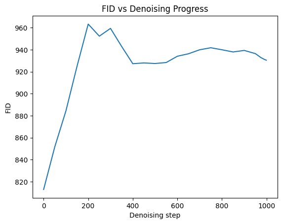

```python
# Calculate FID at different timesteps
# xs contains timestep indices to evaluate
xs = L.range(0, 1000, 50) + [975, 990, 999]

# samples[i] is the image at timestep n_steps-1-i
# We clamp and scale to match expected range
plt.plot(xs, [ie.fid(samples[i].clamp(-0.5, 0.5) * 2) for i in xs])
plt.xlabel('Denoising step')
plt.ylabel('FID')
plt.title('FID vs Denoising Progress');
```

# Understanding `xs` in the FID vs Denoising Progress Plot

## The Code

```
# Calculate FID at different timesteps
# xs contains timestep indices to evaluate
xs = L.range(0, 1000, 50) + [975, 990, 999]

# samples[i] is the image at timestep n_steps-1-i
# We clamp and scale to match expected range
plt.plot(xs, [ie.fid(samples[i].clamp(-0.5, 0.5) * 2) for i in xs])
plt.xlabel('Denoising step')
plt.ylabel('FID')
plt.title('FID vs Denoising Progress');
```

## What is `L`?

`L` is from **fastcore** (imported at the top of the notebook):

```
from fastcore.foundation import L
```

`L` is an enhanced list class from fastcore that provides additional functionality like `.range()`.

## Breaking Down `L.range(0, 1000, 50)`

This creates a list of numbers from 0 to 1000, stepping by 50:

```
L.range(0, 1000, 50)
# Result: [0, 50, 100, 150, 200, 250, 300, 350, 400, 450,
#          500, 550, 600, 650, 700, 750, 800, 850, 900, 950]
```

**Note:** Just like Python's `range()`, it stops **before** 1000, so 1000 is not included.

## Breaking Down `+ [975, 990, 999]`

This adds three more values at the end to capture the **final denoising steps** with finer granularity:

```
L.range(0, 1000, 50) + [975, 990, 999]
# Result: [0, 50, 100, 150, 200, 250, 300, 350, 400, 450,
#          500, 550, 600, 650, 700, 750, 800, 850, 900, 950,
#          975, 990, 999]
```

## Why These Specific Values?

```
┌─────────────────────────────────────────────────────────────────┐
│                    DENOISING PROCESS (1000 steps)                │
├─────────────────────────────────────────────────────────────────┤
│                                                                 │
│  Step 0        Step 500       Step 950    Step 999              │
│    │              │              │           │                  │
│    ▼              ▼              ▼           ▼                  │
│  ┌────┐        ┌────┐        ┌────┐      ┌────┐                │
│  │░░░░│   →    │▒▒▒▒│   →    │▓▓▓▓│  →   │████│                │
│  │░░░░│        │▒▒▒▒│        │▓▓▓▓│      │████│                │
│  └────┘        └────┘        └────┘      └────┘                │
│   Pure          Partial       Almost      Final                 │
│   Noise         Denoised      Clean       Image                 │
│                                                                 │
│  xs samples at:                                                 │
│  [0, 50, 100, 150, ... 900, 950] ← Every 50 steps (coarse)     │
│  [975, 990, 999]                 ← Final steps (fine detail)   │
│                                                                 │
└─────────────────────────────────────────────────────────────────┘
```

### Why Add [975, 990, 999]?

The **final denoising steps** are where the most important details emerge. By adding these values, we can see:

- How FID improves in the **critical final phase**
- Whether the model converges smoothly or has sudden changes
- The exact quality at the **very last step** (999)

## Complete `xs` Values

```
xs = [0, 50, 100, 150, 200, 250, 300, 350, 400, 450,
      500, 550, 600, 650, 700, 750, 800, 850, 900, 950,
      975, 990, 999]

len(xs)  # 23 values total
```

| Range | Values | Purpose |
| --- | --- | --- |
| 0-950 | Every 50 steps | Coarse sampling of denoising progress |
| 975, 990, 999 | Final 3 points | Fine detail in critical final phase |

## How `xs` is Used in the Plot

```
plt.plot(xs, [ie.fid(samples[i].clamp(-0.5, 0.5) * 2) for i in xs])
```

For each value `i` in `xs`:

| Step | Code | What It Does |
| --- | --- | --- |
| 1 | `samples[i]` | Get the image at denoising step `i` |
| 2 | `.clamp(-0.5, 0.5)` | Clamp pixel values to range [-0.5, 0.5] |
| 3 | `* 2` | Scale to range [-1, 1] to match training data |
| 4 | `ie.fid(...)` | Calculate FID score for this image |
| 5 | `plt.plot(xs, [...])` | Plot the point (step, FID) |

## What Does `samples[i]` Contain?

During the DDPM sampling process, `samples` is a list that stores the image at each denoising step:

```
samples = sample(smodel, (256, 1, 32, 32), alpha, alphabar, sigma, n_steps)
# samples[0]   = image after step 0   (still very noisy)
# samples[500] = image after step 500 (partially denoised)
# samples[999] = image after step 999 (final clean image)
```

## Why `.clamp(-0.5, 0.5) * 2`?

This ensures the generated images are in the correct range for the feature extractor:

```
┌─────────────────────────────────────────────────────────────────┐
│                    VALUE RANGE ADJUSTMENT                        │
├─────────────────────────────────────────────────────────────────┤
│                                                                 │
│  Raw samples output:     might be outside [-0.5, 0.5]           │
│                               │                                 │
│                               ▼                                 │
│  .clamp(-0.5, 0.5):      force into range [-0.5, 0.5]          │
│                               │                                 │
│                               ▼                                 │
│  * 2:                    scale to range [-1, 1]                 │
│                               │                                 │
│                               ▼                                 │
│  Final range:            [-1, 1] (matches training data)        │
│                                                                 │
└─────────────────────────────────────────────────────────────────┘
```

The feature extractor (classifier) was trained on images in the range [-1, 1], so we need to match that.

## Expected Plot Result

[output not shown]

## Summary

[output not shown]

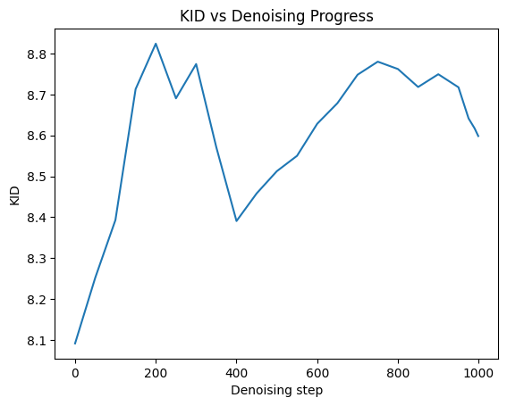

```python
# Same for KID
xs = L.range(0, 1000, 50) + [975, 990, 999]
plt.plot(xs, [ie.kid(samples[i].clamp(-0.5, 0.5) * 2) for i in xs])
plt.xlabel('Denoising step')
plt.ylabel('KID')
plt.title('KID vs Denoising Progress');
```

### 🎮 Interactive: the denoising scoreboard — quality is a curve, not a number

```python
# ============================================================================
# INTERACTIVE -- run this cell. It loads ./interactive_viz/denoise_scoreboard.html
# at full width, sized to fit the visualization (setup cell near the top required).
# Keep the 'interactive_viz' folder in the SAME directory as this notebook.
# ============================================================================
show_viz("interactive_viz/denoise_scoreboard.html", height="820px")
```

[interactive chart not shown]

### Sanity Check: FID/KID of Real Images

What if we evaluate real images? The scores should be very low!

```python
# FID of real images (should be low)
# xb is a batch of real images
ie.fid(xb)
```

```
1.5263671875
```

```python
# KID of real images (should be near zero or slightly negative due to estimation variance)
ie.kid(xb)
```

```
-0.00020105188013985753
```

**What do these results show?**

This confirms our metrics are working correctly - real images score better than generated ones!

## Section 6: Using InceptionV3 (Standard FID)

The standard FID uses features from **InceptionV3** trained on ImageNet, not a custom classifier.

**Why InceptionV3?**

- Standardized: Everyone uses the same model, making results comparable
- General features: Trained on diverse ImageNet, captures general visual concepts
- Industry standard: Published FID scores typically use InceptionV3

```python
!pip install pytorch-fid
```

```
Downloading pytorch_fid-0.3.0-py3-none-any.whl (15 kB)
```

```python
# Import InceptionV3 from pytorch_fid library
# Install with: pip install pytorch-fid
from pytorch_fid.inception import InceptionV3
```

```python
# Demo: tensor.repeat() duplicates a tensor
# We'll need this to convert grayscale to RGB
a = tensor([1, 2, 3])
a.repeat((3, 1))  # Repeat 3 times along first dimension
```

```
tensor([[1, 2, 3],
        [1, 2, 3],
        [1, 2, 3]])
```

**Why do we need repeat?**

InceptionV3 expects RGB images (3 channels), but Fashion MNIST is grayscale (1 channel). We'll repeat the grayscale channel 3 times to create a "fake" RGB image.

```python
class IncepWrap(nn.Module):
    """
    Wrapper around InceptionV3 that:
    1. Converts grayscale to RGB by repeating channels
    2. Returns features from the standard FID layer
    """
    def __init__(self):
        super().__init__()
        # resize_input=True handles resizing to Inception's expected size
        self.m = InceptionV3(resize_input=True)

    def forward(self, x):
        # Convert grayscale to RGB: repeat channel 3 times
        # (B, 1, H, W) -> (B, 3, H, W)
        rgb = x.repeat(1, 3, 1, 1)
        # Get features from Inception (returns a list, we want first element)
        return self.m(rgb)[0]
```

**What does the code above do?**

Creates a wrapper that:

1. **Converts grayscale to RGB**: `x.repeat(1, 3, 1, 1)` copies the single channel 3 times
2. **Runs InceptionV3**: Gets features from the standard layer
3. **Returns features**: Shape will be (batch, 2048)

### 🎮 Interactive: swap the ruler — custom classifier vs InceptionV3

```python
# ============================================================================
# INTERACTIVE -- run this cell. It loads ./interactive_viz/inception_switch_lab.html
# at full width, sized to fit the visualization (setup cell near the top required).
# Keep the 'interactive_viz' folder in the SAME directory as this notebook.
# ============================================================================
show_viz("interactive_viz/inception_switch_lab.html", height="800px")
```

[interactive chart not shown]

```python
# Reload data
tds = dsd.with_transform(transformi)
dls = DataLoaders.from_dd(tds, bs, num_workers=fc.defaults.cpus)
```

```python
import gc
gc.collect(); torch.cuda.empty_cache()

bs = 64          # or 32 — down from 512/256
dls = DataLoaders.from_dd(tds, bs, num_workers=fc.defaults.cpus)
ie = ImageEval(IncepWrap(), dls, cbs=[DeviceCB()])
```

```python
# Create ImageEval with InceptionV3
# ie = ImageEval(IncepWrap(), dls, cbs=[DeviceCB()])
```

```python
%%time
# FID with InceptionV3
ie.fid(s)
```

```
CPU times: user 21.1 s, sys: 150 ms, total: 21.3 s
Wall time: 16 s
```

```
58.84764099121094
```

```python
import gc; gc.collect(); torch.cuda.empty_cache()
```

```python
# FID of real images with InceptionV3
# ie.fid(xb)
ie.fid(xb[:64])
```

```
96.96958923339844
```

```python
%%time
# KID with InceptionV3
# ie.kid(s)
ie.kid(s[:64])
```

```
CPU times: user 1.44 s, sys: 139 ms, total: 1.58 s
Wall time: 1.84 s
```

```
0.007055759429931641
```

```python
# KID of real images with InceptionV3
# ie.kid(xb)
ie.kid(xb[:64])
```

```
-0.0008309483528137207
```

# FID with Custom Classifier vs InceptionV3: What's the Difference?

## Overview

The notebook demonstrates **two different approaches** to calculating FID:

| Section | Feature Extractor | Description |
| --- | --- | --- |
| Sections 2-5 | **Custom Classifier** (trained on Fashion MNIST) | Uses a ResNet-style model trained specifically on the dataset |
| Section 6 | **InceptionV3** (trained on ImageNet) | The industry-standard feature extractor for FID |

**Both use DDPM-generated images** - the difference is only in HOW the features are extracted, not WHAT images are evaluated.

## CRITICAL CLARIFICATION: FID Requires Features from BOTH Real and Generated Images

FID compares **two distributions**:

1. Features from **real images** (Fashion MNIST validation set)
2. Features from **generated images** (DDPM samples)

**The SAME feature extractor must be used for BOTH** to make a fair comparison.

### Sections 2-5: Custom Classifier Extracts Features from BOTH

```
# Feature extractor: Custom classifier trained on Fashion MNIST
model = torch.load('models/data_aug2.pkl')
del(learn.model[8])  # Remove classification head
del(learn.model[7])

# Create ImageEval
ie = ImageEval(model, learn.dls, cbs=[DeviceCB()])
#              ↑            ↑
#              │            └── Real images (Fashion MNIST validation set)
#              └─────────────── Feature extractor

# Inside ImageEval.__init__:
# self.feats = features from REAL images (extracted using custom classifier)

# When we call:
ie.fid(s)  # s = DDPM-generated images
# It extracts features from GENERATED images (using same custom classifier)
# Then compares the two distributions
```

### Section 6: InceptionV3 Extracts Features from BOTH

```
# Feature extractor: InceptionV3 (pretrained on ImageNet)
ie = ImageEval(IncepWrap(), dls, cbs=[DeviceCB()])
#              ↑            ↑
#              │            └── Real images (Fashion MNIST validation set)
#              └─────────────── Feature extractor

# Inside ImageEval.__init__:
# self.feats = features from REAL images (extracted using InceptionV3)

# When we call:
ie.fid(s)  # s = DDPM-generated images
# It extracts features from GENERATED images (using same InceptionV3)
# Then compares the two distributions
```

## Visual Summary: Same Feature Extractor for Both Real and Generated

```
┌─────────────────────────────────────────────────────────────────┐
│                    SECTIONS 2-5: CUSTOM CLASSIFIER               │
├─────────────────────────────────────────────────────────────────┤
│                                                                 │
│   REAL IMAGES                      GENERATED IMAGES             │
│   (Fashion MNIST)                  (from DDPM)                  │
│        │                                │                       │
│        ▼                                ▼                       │
│   ┌──────────────────────────────────────────────┐             │
│   │         CUSTOM CLASSIFIER (512-dim)          │             │
│   │         (same model for both!)               │             │
│   └──────────────────────────────────────────────┘             │
│        │                                │                       │
│        ▼                                ▼                       │
│   Real Features                   Generated Features            │
│   [N, 512]                        [M, 512]                     │
│        │                                │                       │
│        └────────────┬───────────────────┘                       │
│                     ▼                                           │
│              ┌─────────────┐                                    │
│              │ COMPARE FID │                                    │
│              └─────────────┘                                    │
│                                                                 │
└─────────────────────────────────────────────────────────────────┘

┌─────────────────────────────────────────────────────────────────┐
│                    SECTION 6: InceptionV3                        │
├─────────────────────────────────────────────────────────────────┤
│                                                                 │
│   REAL IMAGES                      GENERATED IMAGES             │
│   (Fashion MNIST)                  (from DDPM)                  │
│        │                                │                       │
│        ▼                                ▼                       │
│   ┌──────────────────────────────────────────────┐             │
│   │           InceptionV3 (2048-dim)             │             │
│   │           (same model for both!)             │             │
│   └──────────────────────────────────────────────┘             │
│        │                                │                       │
│        ▼                                ▼                       │
│   Real Features                   Generated Features            │
│   [N, 2048]                       [M, 2048]                    │
│        │                                │                       │
│        └────────────┬───────────────────┘                       │
│                     ▼                                           │
│              ┌─────────────┐                                    │
│              │ COMPARE FID │                                    │
│              └─────────────┘                                    │
│                                                                 │
└─────────────────────────────────────────────────────────────────┘
```

### Key Insight

**The feature extractor must be IDENTICAL for both real and generated images** - that's the only way to fairly compare the distributions!

## Section 2-5: Custom Classifier Approach

### The Feature Extractor

```
# Load a pre-trained Fashion MNIST classifier
model = torch.load('models/data_aug2.pkl')

# Remove the classification head to get features
del(learn.model[8])  # Remove final classification layer
del(learn.model[7])  # Remove pooling/activation layer

# Now model outputs 512-dim features instead of class probabilities
```

### What This Model Is

- A **ResNet-style CNN** trained to classify Fashion MNIST (10 classes)
- Trained specifically on **Fashion MNIST** data
- Outputs **512-dimensional features** after removing the classification head

### How It's Used

```
# Create evaluator with custom classifier
ie = ImageEval(model, learn.dls, cbs=[DeviceCB()])

# Evaluate DDPM-generated images
ie.fid(s)  # s = generated samples from DDPM
ie.kid(s)
```

### Architecture

```
┌─────────────────────────────────────────────────────────────────┐
│              CUSTOM CLASSIFIER (Fashion MNIST)                   │
├─────────────────────────────────────────────────────────────────┤
│                                                                 │
│  Input: [B, 1, 32, 32]  (grayscale Fashion MNIST)              │
│         │                                                       │
│         ▼                                                       │
│  ┌─────────────────────┐                                        │
│  │ ResNet-style layers │                                        │
│  │ (trained on Fashion │                                        │
│  │  MNIST)             │                                        │
│  └─────────────────────┘                                        │
│         │                                                       │
│         ▼                                                       │
│  Output: [B, 512]  (512-dim features)                          │
│                                                                 │
│  Features capture: clothing-specific patterns                   │
│  (shirts, pants, shoes, etc.)                                   │
│                                                                 │
└─────────────────────────────────────────────────────────────────┘
```

## Section 6: InceptionV3 Approach

### The Feature Extractor

```
from pytorch_fid.inception import InceptionV3

class IncepWrap(nn.Module):
    def __init__(self):
        super().__init__()
        self.m = InceptionV3(resize_input=True)

    def forward(self, x):
        # Convert grayscale to RGB
        rgb = x.repeat(1, 3, 1, 1)
        return self.m(rgb)[0]
```

### What This Model Is

- **InceptionV3** pre-trained on **ImageNet** (1000 classes, millions of images)
- The **industry standard** for FID calculation
- Outputs **2048-dimensional features** from the pool3 layer

### How It's Used

```
# Create evaluator with InceptionV3
ie = ImageEval(IncepWrap(), dls, cbs=[DeviceCB()])

# Evaluate the SAME DDPM-generated images
ie.fid(s)  # s = same generated samples from DDPM
ie.kid(s)
```

### Architecture

```
┌─────────────────────────────────────────────────────────────────┐
│                    InceptionV3 (ImageNet)                        │
├─────────────────────────────────────────────────────────────────┤
│                                                                 │
│  Input: [B, 1, 32, 32]  (grayscale Fashion MNIST)              │
│         │                                                       │
│         ▼                                                       │
│  ┌─────────────────────┐                                        │
│  │ x.repeat(1,3,1,1)   │  Convert grayscale → RGB               │
│  └─────────────────────┘                                        │
│         │                                                       │
│         ▼                                                       │
│  [B, 3, 32, 32]  (fake RGB)                                    │
│         │                                                       │
│         ▼                                                       │
│  ┌─────────────────────┐                                        │
│  │ resize_input=True   │  Resize to 299×299 (Inception size)   │
│  └─────────────────────┘                                        │
│         │                                                       │
│         ▼                                                       │
│  ┌─────────────────────┐                                        │
│  │ InceptionV3 layers  │                                        │
│  │ (trained on ImageNet│                                        │
│  │  1000 classes)      │                                        │
│  └─────────────────────┘                                        │
│         │                                                       │
│         ▼                                                       │
│  Output: [B, 2048]  (2048-dim features)                        │
│                                                                 │
│  Features capture: general visual concepts                      │
│  (edges, textures, shapes, objects)                            │
│                                                                 │
└─────────────────────────────────────────────────────────────────┘
```

## Key Differences

| Aspect | Custom Classifier | InceptionV3 |
| --- | --- | --- |
| **Training Data** | Fashion MNIST (60K images, 10 classes) | ImageNet (1.2M images, 1000 classes) |
| **Feature Dim** | 512 | 2048 |
| **Input Size** | 32×32 grayscale | 299×299 RGB |
| **Specificity** | Dataset-specific features | General visual features |
| **Comparability** | Only comparable within your experiments | Comparable with published results |
| **Preprocessing** | None needed | Grayscale→RGB conversion, resizing |

## What Images Are Being Evaluated?

**BOTH approaches evaluate the SAME DDPM-generated images!**

```
# Generate images with DDPM (this happens ONCE, in Section 3)
samples = sample(smodel, (256, 1, 32, 32), alpha, alphabar, sigma, n_steps)
s = samples[-1] * 2 - 1  # Final denoised images

# Section 5: Evaluate with custom classifier
ie_custom = ImageEval(model, learn.dls, cbs=[DeviceCB()])
fid_custom = ie_custom.fid(s)  # Same 's'

# Section 6: Evaluate with InceptionV3
ie_inception = ImageEval(IncepWrap(), dls, cbs=[DeviceCB()])
fid_inception = ie_inception.fid(s)  # Same 's'
```

The only difference is **HOW features are extracted** from those images.

## Visual Comparison: Two Approaches to the Same Problem

[output not shown]

## Why Use Both?

### Custom Classifier (Sections 2-5)

**Pros:**

- Faster (smaller model, no resizing)
- Features specifically tuned for Fashion MNIST
- Good for learning/experimentation

**Cons:**

- Results not comparable to other papers
- Only works for this specific dataset

### InceptionV3 (Section 6)

**Pros:**

- **Industry standard** - results comparable to published papers
- Works for any image dataset
- Well-tested and validated

**Cons:**

- Slower (larger model, needs resizing)
- Requires grayscale→RGB conversion for non-RGB datasets
- Features may not be optimal for specific domains

## Did We Use DDPM for Both?

**YES!** Both sections evaluate images generated by the **same DDPM model**.

```
# This DDPM model is used throughout the notebook
smodel = torch.load('models/fashion_ddpm_mp.pkl').cuda()

# Generate samples (done once)
samples = sample(smodel, (256, 1, 32, 32), alpha, alphabar, sigma, n_steps)
s = samples[-1] * 2 - 1

# 's' is evaluated by BOTH:
# - Custom classifier in Section 5
# - InceptionV3 in Section 6
```

## Complete Picture: What Happens in Each Section

### Sections 2-5 Flow

```
┌─────────────────────────────────────────────────────────────────┐
│                    SECTIONS 2-5 COMPLETE FLOW                    │
├─────────────────────────────────────────────────────────────────┤
│                                                                 │
│  STEP 1: Load Custom Classifier                                 │
│  ───────────────────────────────                                │
│  model = torch.load('models/data_aug2.pkl')                    │
│  del(learn.model[8])  # Remove classification head              │
│  del(learn.model[7])                                           │
│                                                                 │
│  STEP 2: Create ImageEval                                       │
│  ────────────────────────                                       │
│  ie = ImageEval(model, learn.dls, cbs=[DeviceCB()])            │
│       │                                                         │
│       └── This extracts features from REAL images              │
│           using the custom classifier and stores them           │
│                                                                 │
│  STEP 3: Generate Images with DDPM                              │
│  ─────────────────────────────────                              │
│  samples = sample(smodel, ...)                                 │
│  s = samples[-1] * 2 - 1  # Generated images                   │
│                                                                 │
│  STEP 4: Calculate FID                                          │
│  ─────────────────────                                          │
│  ie.fid(s)                                                     │
│       │                                                         │
│       └── This extracts features from GENERATED images         │
│           using the SAME custom classifier                      │
│           Then compares with pre-computed real features         │
│                                                                 │
└─────────────────────────────────────────────────────────────────┘
```

### Section 6 Flow

```
┌─────────────────────────────────────────────────────────────────┐
│                    SECTION 6 COMPLETE FLOW                       │
├─────────────────────────────────────────────────────────────────┤
│                                                                 │
│  STEP 1: Create InceptionV3 Wrapper                             │
│  ──────────────────────────────────                             │
│  class IncepWrap wraps InceptionV3 with:                       │
│    - Grayscale → RGB conversion                                │
│    - Automatic resizing to 299×299                             │
│                                                                 │
│  STEP 2: Create ImageEval                                       │
│  ────────────────────────                                       │
│  ie = ImageEval(IncepWrap(), dls, cbs=[DeviceCB()])            │
│       │                                                         │
│       └── This extracts features from REAL images              │
│           using InceptionV3 and stores them                     │
│                                                                 │
│  STEP 3: Use SAME Generated Images from DDPM                    │
│  ───────────────────────────────────────────                    │
│  s = samples[-1] * 2 - 1  # Same generated images as before    │
│                                                                 │
│  STEP 4: Calculate FID                                          │
│  ─────────────────────                                          │
│  ie.fid(s)                                                     │
│       │                                                         │
│       └── This extracts features from GENERATED images         │
│           using the SAME InceptionV3                            │
│           Then compares with pre-computed real features         │
│                                                                 │
└─────────────────────────────────────────────────────────────────┘
```

## Summary Tables

### What Gets Compared

|  | Real Images | Generated Images | Feature Extractor |
| --- | --- | --- | --- |
| **Sections 2-5** | Fashion MNIST validation | DDPM samples | Custom Classifier (512-dim) |
| **Section 6** | Fashion MNIST validation | DDPM samples | InceptionV3 (2048-dim) |

### Final Summary

| Question | Answer |
| --- | --- |
| What generates the images? | DDPM (same model for both sections) |
| What's different? | The feature extractor used for FID calculation |
| Section 2-5 feature extractor | Custom ResNet trained on Fashion MNIST (512-dim) |
| Section 6 feature extractor | InceptionV3 trained on ImageNet (2048-dim) |
| Does each approach extract features from real images? | **YES** - during `ImageEval.__init__` |
| Does each approach extract features from generated images? | **YES** - when calling `ie.fid(s)` |
| Must the same extractor be used for both? | **YES** - fair comparison requires identical feature extraction |
| Which is "correct"? | InceptionV3 is the standard; custom is for learning |
| Why show both? | Educational: understand FID concept first, then use standard |
| Are results comparable? | Only InceptionV3 results can be compared to published FID scores |

**Comparing Results:**

[output not shown]

**Why are InceptionV3 FID scores higher?**

- InceptionV3 was trained on natural images (ImageNet), not fashion items
- The features may be less relevant for Fashion MNIST
- However, using InceptionV3 makes scores comparable with other papers

# Understanding `ie.fid(xb)` - The "Sanity Check"

## The Confusion

When we see this code:

```
# FID of real images (should be low)
# xb is a batch of real images
ie.fid(xb)
```

It seems like we're comparing real images against real images. If `ImageEval` stores features from real images, and `xb` is also real images, are we comparing the same images against themselves?

**No! They are DIFFERENT sets of real images!**

## Key Insight: `self.feats` vs `xb` are DIFFERENT Sets

### What `self.feats` Contains

When `ImageEval` is created:

```
ie = ImageEval(model, learn.dls, cbs=[DeviceCB()])
```

Inside `__init__`:

```
# capture_preds() runs on the VALIDATION set (dls.valid)
self.feats = self.learn.capture_preds()[0].float().cpu().squeeze()
```

`capture_preds()` extracts features from the **validation set** (`dls.valid`), which contains **10,000 images** (the full Fashion MNIST validation set).

### What `xb` Contains

Earlier in the notebook:

```
# ONE BATCH from the TRAINING set!
b = xb, yb = next(iter(dls.train))
```

`xb` is just **one batch (512 images)** from the **training set**, NOT the validation set!

## What `ie.fid(xb)` Actually Compares

[output not shown]

### The Comparison

|  | `self.feats` | `xb` |
| --- | --- | --- |
| **Source** | Validation set | Training set |
| **Number of images** | 10,000 | 512 (one batch) |
| **When extracted** | During `ImageEval.__init__` | When `ie.fid(xb)` is called |
| **Type of images** | Real (Fashion MNIST) | Real (Fashion MNIST) |

**Both are REAL images, just from DIFFERENT splits of the dataset!**

Even though **both are real images**, FID is not exactly zero because:

1. **Different splits**: Validation vs Training sets have slightly different distributions
2. **Sample size mismatch**: Only 512 training images vs 10,000 validation images
3. **Estimation variance**: Statistical estimation of mean and covariance has some noise
4. **Sampling randomness**: The specific batch `xb` might not perfectly represent the full training distribution

## Why Do This "Sanity Check"?

This test verifies that the FID metric is working correctly:

[output not shown]